# Một số mô hình hồi quy và áp dụng cho tập dữ liệu Concrete_data.csv

Giảng viên hướng dẫn: Th.S Nguyễn Phát Đạt

Nhóm sinh viên thực hiện: Nhóm 1 - Đinh Minh Hải, Trương Như Ý, Lê Hoàng Quân, Bùi Quang Huy, Phù Quốc Vinh, Lý Kiều Văn, Đặng Nguyễn Anh Tuấn

2024-08-14

#### Mã lớp học phần: MATH140701

# $1$. Đặt vấn đề (Introduction)

Bê tông là một trong những loại vật liệu cực kỳ quan trọng và không thể thiếu được trong ngành công nghiệp xây dựng. Việc sử dụng bê tông là một lựa chọn vô cùng hữu hiệu cho thi công và đảm bảo tuổi thọ công trình xây dựng được dài hơn. Ngoài ra việc sử dụng bê tông cho công trình chủ thầu và chủ đầu tư còn tiết kiệm được nhiều thời gian và chi phí, tiết kiệm cho chủ đầu tư bởi việc thi công được diễn ra nhanh chóng và thuận tiện nhờ có bê tông mà các công trình bê tông được hoàn thành đúng thời gian hợp đồng thi công tiết kiệm chi phí và giảm sức lao động của con người. Bởi sự quan trọng của betong trong xây dựng mà việc áp dụng các tiến bộ khoa học kỹ thuật vào trong công nghệ chế tạo bê tông đang được tất cả các quốc gia đẩy mạnh sự nghiên cứu để có thể tạo ra những kết cấu bê tông, bê tông cốt thép hay những loại hình bê tông cốt sợi đạt được những chất lượng cao nhất, bền nhất và có tính thẩm mỹ nhất để có thể cải thiện tối đa chất lượng công trình. Các nguyên liệu để đổ bê tông là một trong những yếu tố quan trọng ảnh hưởng đến cường độ bê tông. Các nguyên liệu bao gồm nước, đá, cát,… sẽ làm tăng hoặc giảm độ liên kết của bê tông, làm cho khả năng chịu nén bị ảnh hưởng. Cường độ chịu nén của bê tông hiểu đơn giản là ứng suất nén có thể phá hủy của bê tông, được tính bằng lực trên một đơn vị diện tích như H/mm2, kg/cm2,… Cường độ chịu nén là một đặc trưng cơ bản của bê tông, nó phản ánh khả năng chịu lực của bê tông.Như vậy, có thể thấy cường độ chịu nén là một trong những yếu tố cho biết bê tông có tốt hay không. Ở bài viết này, nhóm chúng tôi sẽ tìm hiểu và phân tích mối tương quan giữa cường độ nén của bê tông với các yếu tố là các thành phần của bê tông như nước, đá, cát, chất lượng xi măng, phụ gia bê tông, tỷ lệ pha trộn….là như thế nào với mong muốn tìm ra được thành phần quan trọng và ảnh hưởng đến chất lượng của bê tông. Từ đó góp phần vào việc nghiên cứu, sản xuất ra loại bê tông có chất lượng ngày càng cải thiện.

# $2$. Cơ sở toán học (Preliminaries)

# 2.1. Robust Regression

## 2.1.1. Breakdown(tạm dịch: điểm gãy)

The finite sample breakdown point(Điểm gãy của mẫu hữu hạn $n$) của một ước lượng là tỉ lệ $\alpha$, mà giá trị của $n\alpha$ điểm dữ liệu lớn tùy ý. Do đó, ảnh hưởng xấu đến các giá trị ước lượng. Xét trung bình của mẫu $x_1,x_2,\dots,x_n$, ta có

$$\overline{x}_n=\frac{1}{n}\sum_{i=1}^{n}x_i=\frac{1}{n}\left[\sum_{i=1}^{n-1}x_i+x_n\right]=\frac{n-1}{n}\overline{x}_{n-1}+\frac{1}{n}x_n$$

Rõ ràng, khi $x_n$ đủ lớn thì $\overline{x}_n$ cũng có thể trở nên lớn tùy ý. Khi đó, $\frac{1}{n}$ là điểm “gãy” hữu hạn cho ước lượng trung bình của mẫu. Mặt khác, không như trung bình, trung vị mẫu - một ước lượng của trung vị tổng thể có thể chấp nhận được đến $50\%$ các giá trị xấu (nghĩa là có thể một nửa tập dữ liệu trở nên rất lớn, hoặc rất nhỏ, nhưng trung vị mẫu vẫn không bị ảnh hưởng). Thông thường, điểm gãy hữu hạn là một hàm số của kích thước mẫu $n$. Để có được một con số cụ thể, ta dùng khái niệm **điểm gãy tiệm cận** - là giới hạn của điểm “gãy” hữu hạn khi $n\to\infty$.

## 2.1.2. Ước lượng hợp lý cực đại (*M*-estimation)

Ta chỉ xét mô hình hồi quy tuyến tính với biến đầu ra thứ $i$ của $n$ quan trắc.

$$y_i=\beta_0+\beta_1x_{i1}+\beta_2x_{i2}+\dots+\beta_kx_{ik}+\varepsilon_i=\mathbf{x_i}^T\mathbf{\beta}+\varepsilon_i$$

Đặt một ước lượng $\mathbf{b}$ cho $\beta$ thì mô hình phù hợp là

$$\hat{y}_i=b_0+b_1x_{i1}+b_2x_{i2}+\dots+b_kx_{ik}=\mathbf{x_i}^T\mathbf{b}$$
và các phần dư lúc này được cho bởi $e_i=y_i-\hat{y}_i$.

Với ước lượng hợp lý cực đại, giá trị ước lượng $\mathbf{b}$ được xác định bằng việc tối thiểu hóa một hàm mục tiêu cụ thể trên tất cả các thành phần của $\mathbf{b}$

$$\sum_{i=1}^{n}\rho\left(e_i\right)=\sum_{i=1}^{n}\rho\left(y_i-\mathbf{x_i}^T\mathbf{b}\right)$$

trong đó hàm $\rho$ cho phép từng phần dư ảnh hưởng lên hàm mục tiêu. Một hàm $\rho$ hợp lý nên thỏa mãn các tính chất sau:

- Luôn không âm: $\rho\left(e\right)\geq 0$.
- Bằng $0$ khi đối số bằng $0$: $\rho\left(0\right)=0$.
- Đối xứng: $\rho\left(e\right)=\rho\left(-e\right)$.
- Đơn điệu tăng theo $\left|e\right|$: Nếu $\left|e\right|>\left|e'\right|$ thì $\rho\left(e\right)>\rho\left(e'\right)$.

Ta có bổ đề sau $f(\mathbf{x}) = \mathbf{a}^T\mathbf{x}$

Giả sử $\mathbf{a}, \mathbf{x} \in \mathbb{R}^n$, ta viết lại
$$f(\mathbf{x}) = \mathbf{a}^T\mathbf{x} = a_1 x_1 + a_2 x_2 + \dots +
a_nx_n$$

Nhận thấy $\dfrac{\partial f(\mathbf{x})}{\partial x_i} = a_i, ~ \forall i = 1, 2\dots, n$.
$$\dfrac{\partial f(\mathbf{x})}{\partial x_i} = a_i, ~ \forall i = 1,
2\dots, n$$

Vậy,
$$\nabla_{\mathbf{x}}
(\mathbf{a}^T\mathbf{x}) = \left[\begin{matrix} a_1 & a_2 &
\dots & a_n \end{matrix}\right]^T = \mathbf{a}$$

Ngoài ra, vì $\mathbf{a}^T\mathbf{x} = \mathbf{x}^T\mathbf{a}$ nên $\nabla_{\mathbf{x}} (\mathbf{x}^T\mathbf{a}) = \mathbf{a}$.
$$\nabla (\mathbf{x}^T\mathbf{a}) = \mathbf{a}$$

Đặt $\psi=\rho'$ là đạo hàm của $\rho$ thì $\psi$ được gọi là “đường cong ảnh hưởng” (influence curve). Lấy đạo hàm của hàm mục tiêu theo các hệ số $\mathbf{b}$ và cho các đạo hàm riêng bằng 0, ta được hệ gồm $k+1$ phương trình ước lượng cho các hệ số

$$\left(\sum_{i=1}^{n}\rho\left(e_i\right)\right)^{'}=\left(\sum_{i=1}^{n}\rho\left(y_i-\mathbf{x_i}^T\mathbf{b}\right)\right)^{'}=\sum_{i=1}^{n}\left(\rho\left(y_i-\mathbf{x_i}^T\mathbf{b}\right)\right)^{'}=\sum_{i=1}^{n}\psi\left(y_i-\mathbf{x_i}^T\mathbf{b}\right)\left(y_i-\mathbf{x_i}^T\mathbf{b}\right)^{'}=
-\sum_{i=1}^{n}\psi\left(y_i-\mathbf{x_i}^T\mathbf{b}\right)\mathbf{x_i}
= 0$$
Suy ra
$$\sum_{i=1}^{n}\psi\left(y_i-\mathbf{x_i}^T\mathbf{b}\right)\mathbf{x_i}=0$$
Ta định nghĩa **hàm trọng số** $w\left(e\right)=\psi\left(e\right)/e$ và đặt $w_i=w\left(e_i\right)$

## 2.1.3. Quy trình tính toán

Các phương trình ước lượng có thể được viết lại thành $\sum_{i=1}^{n}w_i\left(y_i-\mathbf{x_i}^T\mathbf{b}\right)\mathbf{x_i}=0$. Giải các phương trình trên tương đương với bài toán “bình phương tối thiểu có trọng số” - tối thiểu hóa $\sum w_i^2e_i^2$. Các trọng số, tuy nhiên lại phụ thuộc vào phần dư, phân dư phụ thuộc vào các hệ số ước lượng, và các hệ số ước lượng lại phụ thuộc vào trọng số - tạo thành một vòng lặp. Như vậy, một nghiệm lặp (bình phương tối thiểu có trọng số lặp lại) cần có các yêu cầu sau:

1. Chọn ước lượng khởi đầu $\mathbf{b}^{(0)}$, chẳng hạn như ước lượng bình phương tối thiểu.
2. Với mỗi lần lặp $t$, tính phần dư $e^{(t-1)}$ và trọng số liên kết $w_i^{(t-1)}=w\left[e^{(t-1)}\right]$ từ lần lặp trước.
3. Giải hệ sau để tìm ước lượng bình phương tối thiểu có trọng số:
   $$\mathbf{b}^{(t)}=\left[\mathbf{X}^T\mathbf{W}^{(t-1)}\mathbf{X}\right]^{-1}\mathbf{X}^T\mathbf{W}^{(t-1)}\mathbf{y}$$
   trong đó $\mathbf{X}$ là ma trận của mô hình, với $\mathbf{x_i}$ là dòng thứ $i$ ma trận đó, và $\mathbf{W}^{(t-1)}=\mathrm{diag}\left\{w_i^{(t-1)}\right\}$ là ma trận trọng số hiện tại. Bước 2 và 3 được lặp lại đến khi các hệ số ước lượng hội tụ. Ma trận của hiệp phương sai tiệm cận của $\mathbf{b}$ là
   $$\mathcal{V}\left(\mathbf{b}\right)=\frac{E\left[\psi^2\right]}{\left(E\left[\psi'\right]\right)^2}\left(\mathbf{X}^T\mathbf{X}\right)^{-1}$$
   Dùng $\sum\left[\psi\left(e_1\right)\right]^2$ để ước lượng $E\left[\psi^2\right]$ và $\left[\frac{\psi'\left(e_i\right)}{n}\right]^2$ để ước lượng $\left(E\left[\psi'\right]\right)^2$ cho ta ước lượng của ma trận hiệp phương sai tiệm cận $\hat{\mathcal{V}}\left(\mathbf{b}\right)$ (cái mà không đáng tin đối với mẫu nhỏ).

## 2.1.4. Hàm mục tiêu

| Phương pháp | Hàm mục tiêu | Hàm trọng số |
| --- | --- | --- |
| Least Squares | $\rho\left(e\right)=e^2$ | $w\left(e\right)=1$ |
| Huber | $\rho\left(e\right)=\left\{\begin{array}{cl} \frac{1}{2}e^2&\text{với}\;\left\|e\right\|\leq k\\ k\left\|e\right\|-\frac{1}{2}k^2&\text{với}\;\left\|e\right\|>k\\ \end{array}\right.$ | $w\left(e\right)=\left\{\begin{array}{cl} 1&\text{với}\;\left\|e\right\|\leq k\\ k/\left\|e\right\|&\text{với}\;\left\|e\right\|>k\\ \end{array}\right.$ |
| Bisquare | $\rho\left(e\right)=\left\{\begin{array}{cl} \frac{k^2}{6}\left\{1-\left[1-\left(\frac{e}{k}\right)^2\right]^3\right\}&\text{với}\;\left\|e\right\|\leq k\\ \frac{k^2}{6}&\text{với}\;\left\|e\right\|>k… | $w\left(e\right)=\left\{\begin{array}{cl} \left[1-\left(\frac{e}{k}\right)^2\right]^2&\text{với}\;\left\|e\right\|\leq k\\ 0&\text{với}\;\left\|e\right\|>k\\ \end{array}\right.$ |

Hàm mục tiêu của hai phương pháp bình phương tối thiểu(PPBPTT) và Huber đều tăng mà không bị chặn khi phần dư $e$ đi từ $0$, nhưng hàm mục tiểu của phương pháp bình phương có trọng số tăng nhanh hơn. Ngược lại, hàm mục tiêu của phương pháp song bình phương thậm chí không thay đổi khi $\left|e\right|>k$.

PPBPTT đặt trọng số như nhau cho mỗi quan trắc; trọng số của ước lượng Huber giảm khi $\left|e\right|>k$ và trọng số của ước lượng song bình phương cũng giảm khi $e$ xuất phát từ $0$ và bằng $0$ khi $\left|e\right|>k$.

Giá trị $k$ của các ước lượng Huber vàsong bình phương được gọi là **hằng số điều chỉnh** - giá trị $k$ nhỏ tạo ra nhiều cản trở cho các giá trị ngoại lai, nhưng hiệu quả lại thấp hơn khi các sai số có phân phối chuẩn. Hằng số điều chỉnh thường được chọn để cho hiệu quả cao một cách hợp lý trong trường hợp thông thường, cụ thể là $k=1.345\sigma$ với PP Huber và $k=4.685\sigma$ với PP song bình phương ($\sigma$ là độ lệch chuẩn của sai số) cho hiệu quả đến $95\%$ khi sai số là chuẩn và vẫn đảm bảo tốt với các quan trắc ngoại lai.

Trong ứng dụng, ta cần một ước lượng của độ lệch chuẩn của các sai số để sử dụng các kết quả này. Thông thường, một phương pháp Robust về mức độ phân tán được ưu tiên sử dụng hơn độ lệch chuẩn của phần dư. Ví dụ, một cách tiếp cận phổ biến là lấy $\hat{\sigma}=\mathrm{MAR}/0.6745$, với $\mathrm{MAR}$ là trung vị tuyệt đối của phần dư.

# 2.2. *AIC*(Akaike information criterion)

Akaike (1973) rút ra một tiêu chí từ các lý thuyết thông tin, được gọi là tiêu chí thông tin Akaike ($AIC$). $AIC$ có thể được xem như một xấp xỉ dựa trên dữ liệu cho hàm chênh lệch Kullback-Leibler giữa mô hình ứng viên và mô hình thực. Nó có dạng tổng quát sau:

$$AIC = n × \textrm{log-likelihood} + 2 ×
\textrm{số tham số}$$

Khi áp dụng cho các mô hình Gaussian hoặc bình thường, nó trở thành một hằng số,

$$AIC \simeq n · log(SSE_p) +
2p$$

Phần đầu tiên $n \cdot log(SSE)$ đo lường mức độ phù hợp của mô hình, sau đó bị phạt bởi độ phức tạp của mô hình ở phần còn lại $2p$. Hằng số $2$ thường được gọi là độ phức tạp hoặc tham số phạt. $AIC$ càng nhỏ dẫn đến mô hình đề xuất càng tốt. Dựa trên các quan sát thấy $AIC$ có xu hướng overfit khi cỡ mẫu tương đối nhỏ, Hurvich và Tsai (1989) đã đề xuất một phiên bản hiệu chỉnh sai lệch, được gọi là $AIC_C$, được đưa ra bởi
$$AIC_C \simeq n · log(SSE) + \frac{n
· (n + p + 1)}{n − p − 3}$$

# 2.3. *BIC*(Bayesian information criterion)

BIC, được cho bởi

$$BIC\simeq
n\cdot\log\left(SSE\right)+p\cdot\log \left(n\right)$$

đặt một mức phạt (penalty) rộng hơn cho việc **quá phù hợp** (overfitting). Tiêu chí dựa trên thông tin(information-based) đã ứng dụng rộng rãi trong các ứng dụng thống kê chủ yếu là do sự mở rộng dễ dàng sang các mô hình hồi quy khác.

Trong các mẫu lớn, một tiêu chí lựa chọn mô hình được cho là *hiệu quả tiệm cận*(asymtotically efficient) nếu nó được sử dụng để chọn mô hình có trung bình sai số bình phương nhỏ nhất và được cho là **nhất quán** nếu nó chọn mô hình thực với xác suất là một. Theo cách phân loại này, $AIC$ và $AIC_C$ đều là tiêu chí hiệu quả tiệm cận trong khi $BIC$ là tiêu chí nhất quán. Trong sự tác động của các yếu tố khác, hiệu suất của các tiêu chí này phụ thuộc vào kích thước mẫu có sẵn và tỷ lệ tín hiệu nhiễu (signal-to-noise). Cụ thể là, McQuarrie và Tsai (1998) đã chỉ ra rằng $AIC$ hoạt động tốt nhất đối với mẫu có kích thước vừa phải, $AIC_C$ cung cấp lựa chọn hiệu quả nhất với các mẫu nhỏ, trong khi $BIC$ phù hợp nhất với các mẫu lớn có tín hiệu tương đối mạnh.

# 2.4. Đa cộng tuyến và tỉ số phóng đại phương sai *VIF*

Khi phân tích một tập dữ liệu, đa cộng tuyến tồn tại khi có mối quan hệ tuyến tính hoặc tương quan giữa một hoặc nhiều biến đầu vào. Khi đó, về măt ý nghĩa thống kê của các biến độc lập sẽ bị giảm đi. Vì đa cộng tuyến cho thấy các biến đầu vào có ảnh hưởng lẫn nhau từ đó mà chúng không thực sự độc lập và rất khó để kiểm tra mức độ ảnh hưởng của các biến độc lập đến biến phụ thuộc trong mô hình hồi quy. Để khắc phục tình trạng này, ta có nhiều công cụ để giải quyết, ở bài viết này, chúng tôi đã sử dụng công cụ tỉ số phóng đại phương sai ($VIF$). Tỉ số phóng đại phương sai ($VIF$) là thước đo mức độ đa cộng tuyến trong một tập hợp nhiều biến hồi quy. $VIF$ cho một biến mô hình hồi quy bằng tỷ số giữa phương sai của mô hình tổng thể với phương sai của một mô hình có một biến độc lập duy nhất đó. Tỷ lệ này được tính cho từng biến độc lập. $VIF$ cao chỉ ra rằng biến độc lập liên quan có tính tương đồng cao với các biến khác trong mô hình. Dựa vào tỉ số $VIF$, ta có thể tìm ra biến có mối tương quan mạnh với các biến còn lại và loại biến đó đi. Ta thực hiện liên tiếp cho đến khi mô hình còn lại các biến có tỉ số $VIF$ nhỏ hơn 10.

# 2.5. Tính tự tương quan và kiểm định Durbin-Watson

Tự tương quan có thể hiểu đơn giản là hiện tượng mà các giá trị sai số có mối tương quan tuyến tính với nhau. Hiện tượng này vi phạm giả thuyết trong mô hình hồi quy tuyến tính cổ điển đó là giả định quan hệ tự tương quan không tồn tại trong các sai số. Giá trị biểu thị sự tự tương quan từ $-1$ đến $1$. Khi gá trị bằng $0$ thì không có sự tự tương quan, giá trị nhở hơn $0$ thì sự tương quan âm và giá trị lớn hơn $0$ thì là sự tự tương quan dương. Biểu đồ được cho bởi hình dưới đây (Tham khảo tại [link](https://www.reneshbedre.com/blog/durbin-watson-test.html)):

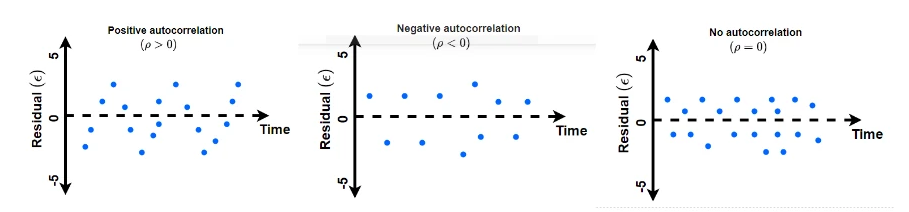

Picture1

Khi đó, việc xuất hiện hiện tượng tự tương quan sẽ làm cho mô hình hồi quy không còn đáng tin cậy về độ chính xác. Vì vậy, khi tiến hành phân tích hồi quy tuyến tín, ta cần kiềm tra và loại bỏ các biến có tính tự tương quan. CÓ nhiều cách để thực hiện công việc này, ở bài viết này, nhóm chúng tôi xin được giới thiệu đến cách thức kiểm định Durbin Watson (DW).

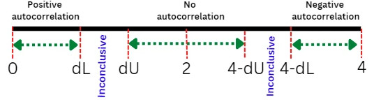

Picture2

Trong đó, giá trị tới hạn $d_L, d_U$ lấy từ bảng giá trị tới hạn từ nguồn sau: [link](https://www3.nd.edu/~wevans1/econ30331/Durbin_Watson_tables.pdf).

# $3$. Giải quyết vấn đề (Methods)

Bước đầu chúng tôi khai báo các thư viện cần sử dụng trong phân tích R

```r
library(dplyr)
library(tidyverse)
library(regclass)
library(robustbase)
library(reshape2)
library(summarytools)
library(MASS)
library(lmtest)
library(stats)
library(car)
```

## 3.1. Mô tả tập dữ liệu “Concrete_Data.csv”

Tập dữ liệu được lấy từ [link](https://www.kaggle.com/datasets/maajdl/yeh-concret-data).

Dữ liệu được lấy từ $1030$ điểm dữ liệu, trích dẫn từ một đơn vị phòng thí nghiệm tại Chung-Hua University, Hsin Chu, Taiwan 30067, R.O.C.

Tập dữ liệu bao gồm 8 biến đầu vào, là lượng chất được tính bằng đơn vị $kg$ có trong $a (m^3)$ hỗn hợp:

1. Cement : Xi măng.
2. Blast Furnace Slag: Xỉ hạt lò cao nghiền mịn.
3. Fly Ash: Tro bay.
4. Water: Nước.
5. Superplasticizer: Phụ gia siêu dẻo.
6. Coarse Aggregate: cốt liệu thô, tổ hợp hạt thô, sỏi, đá.
7. Fine Aggregate: Cốt liệu mịn có thể là cát tự nhiên, cát nghiền và hỗn hợp từ cát tự nhiên và cát nghiền.
8. Age (day): Tuổi của betong (Ngày)

Và một biến đầu ra là Concrete compressive strength(MPa, megapascals): Sức chịu nén betong (cường độ nén của betong).

```r
################################################################################
################################################################################
# Prepare data
setwd("D:/Minh_Hai_D/7_HCMUE_Semester5/1-advanced_probability/4_Tieu_luan_cuoi_ky/Data/concrete_data")
data = read.csv("Concrete_Data.csv", header = TRUE)
head(data)
```

```
##   Cement..component.1..kg.in.a.m.3.mixture.
## 1                                     540.0
## 2                                     540.0
## 3                                     332.5
## 4                                     332.5
## 5                                     198.6
## 6                                     266.0
##   Blast.Furnace.Slag..component.2..kg.in.a.m.3.mixture.
## 1                                                   0.0
## 2                                                   0.0
## 3                                                 142.5
## 4                                                 142.5
## 5                                                 132.4
## 6                                                 114.0
##   Fly.Ash..component.3..kg.in.a.m.3.mixture.
```

[output cut: 41 more lines]

```r
colnames_standfor = colnames(data)
colnames(data) <- c("Cem_com","BFS","FA","Water","SPz", "CA", "FA.1", "Age", "CCS")
```

Ta có bảng phân tích khái quát các cột dữ liệu sau đây.

```r
# summary data and do descriptive statistics
summary(data)
```

```
##     Cem_com           BFS              FA             Water
##  Min.   :102.0   Min.   :  0.0   Min.   :  0.00   Min.   :121.8
##  1st Qu.:192.4   1st Qu.:  0.0   1st Qu.:  0.00   1st Qu.:164.9
##  Median :272.9   Median : 22.0   Median :  0.00   Median :185.0
##  Mean   :281.2   Mean   : 73.9   Mean   : 54.19   Mean   :181.6
##  3rd Qu.:350.0   3rd Qu.:142.9   3rd Qu.:118.30   3rd Qu.:192.0
##  Max.   :540.0   Max.   :359.4   Max.   :200.10   Max.   :247.0
##       SPz               CA              FA.1            Age
##  Min.   : 0.000   Min.   : 801.0   Min.   :594.0   Min.   :  1.00
##  1st Qu.: 0.000   1st Qu.: 932.0   1st Qu.:731.0   1st Qu.:  7.00
##  Median : 6.400   Median : 968.0   Median :779.5   Median : 28.00
##  Mean   : 6.205   Mean   : 972.9   Mean   :773.6   Mean   : 45.66
##  3rd Qu.:10.200   3rd Qu.:1029.4   3rd Qu.:824.0   3rd Qu.: 56.00
##  Max.   :32.200   Max.   :1145.0   Max.   :992.6   Max.   :365.00
##       CCS
##  Min.   : 2.33
##  1st Qu.:23.71
##  Median :34.45
##  Mean   :35.82
##  3rd Qu.:46.13
##  Max.   :82.60
```

```r
descr(data)
```

```
## Descriptive Statistics
## data
## N: 1030
##
##                         Age       BFS        CA       CCS   Cem_com        FA      FA.1       SPz     Water
## ----------------- --------- --------- --------- --------- --------- --------- --------- --------- ---------
##              Mean     45.66     73.90    972.92     35.82    281.17     54.19    773.58      6.20    181.57
##           Std.Dev     63.17     86.28     77.75     16.71    104.51     64.00     80.18      5.97     21.35
##               Min      1.00      0.00    801.00      2.33    102.00      0.00    594.00      0.00    121.80
##                Q1      7.00      0.00    932.00     23.70    192.00      0.00    730.40      0.00    164.90
##            Median     28.00     22.00    968.00     34.44    272.90      0.00    779.50      6.40    185.00
##                Q3     56.00    143.00   1029.40     46.20    350.00    118.30    824.00     10.20    192.00
##               Max    365.00    359.40   1145.00     82.60    540.00    200.10    992.60     32.20    247.00
##               MAD     31.13     32.62     68.64     16.20    117.72      0.00     67.46      7.86     19.27
##               IQR     49.00    142.95     97.40     22.43    157.62    118.30     93.05     10.20     27.10
##                CV      1.38      1.17      0.08      0.47      0.37      1.18      0.10      0.96      0.12
##          Skewness      3.26      0.80     -0.04      0.42      0.51      0.54     -0.25      0.90      0.07
##       SE.Skewness      0.08      0.08      0.08      0.08      0.08      0.08      0.08      0.08      0.08
##          Kurtosis     12.07     -0.52     -0.61     -0.32     -0.53     -1.33     -0.11      1.39      0.11
##           N.Valid   1030.00   1030.00   1030.00   1030.00   1030.00   1030.00   1030.00   1030.00   1030.00
##         Pct.Valid    100.00    100.00    100.00    100.00    100.00    100.00    100.00    100.00    100.00
```

Để đơn giản cho việc gọi biến và phân tích, ta đặt tên gọi theo các biến đầu vào như sau:

```r
################################################################################
################################################################################
# Prepare the variables
colnames(data)
```

```
## [1] "Cem_com" "BFS"     "FA"      "Water"   "SPz"     "CA"      "FA.1"
## [8] "Age"     "CCS"
```

```r
Y <- data$CCS
head(Y)
```

```
## [1] 79.99 61.89 40.27 41.05 44.30 47.03
```

```r
X1 <- data$Cem_com
head(X1)
```

```
## [1] 540.0 540.0 332.5 332.5 198.6 266.0
```

```r
X2 <- data$BFS
head(X2)
```

```
## [1]   0.0   0.0 142.5 142.5 132.4 114.0
```

```r
X3 <- data$FA
head(X3)
```

```
## [1] 0 0 0 0 0 0
```

```r
X4 <- data$Water
head(X4)
```

```
## [1] 162 162 228 228 192 228
```

```r
X5 <- data$SPz
head(X5)
```

```
## [1] 2.5 2.5 0.0 0.0 0.0 0.0
```

```r
X6 <- data$CA
head(X6)
```

```
## [1] 1040.0 1055.0  932.0  932.0  978.4  932.0
```

```r
X7 <- data$FA.1
head(X7)
```

```
## [1] 676.0 676.0 594.0 594.0 825.5 670.0
```

```r
X8 <- data$Age
head(X8)
```

```
## [1]  28  28 270 365 360  90
```

# 3.2. Loại bỏ dữ liệu ngoại lai(outliers)

## 3.2.1. Phát hiện dữ liệu ngoại lai bằng biểu đồ hộp(box plot)

```r
data_long <- melt(data)         # Reshaping data frame
head(data_long)
```

```
##   variable value
## 1  Cem_com 540.0
## 2  Cem_com 540.0
## 3  Cem_com 332.5
## 4  Cem_com 332.5
## 5  Cem_com 198.6
## 6  Cem_com 266.0
```

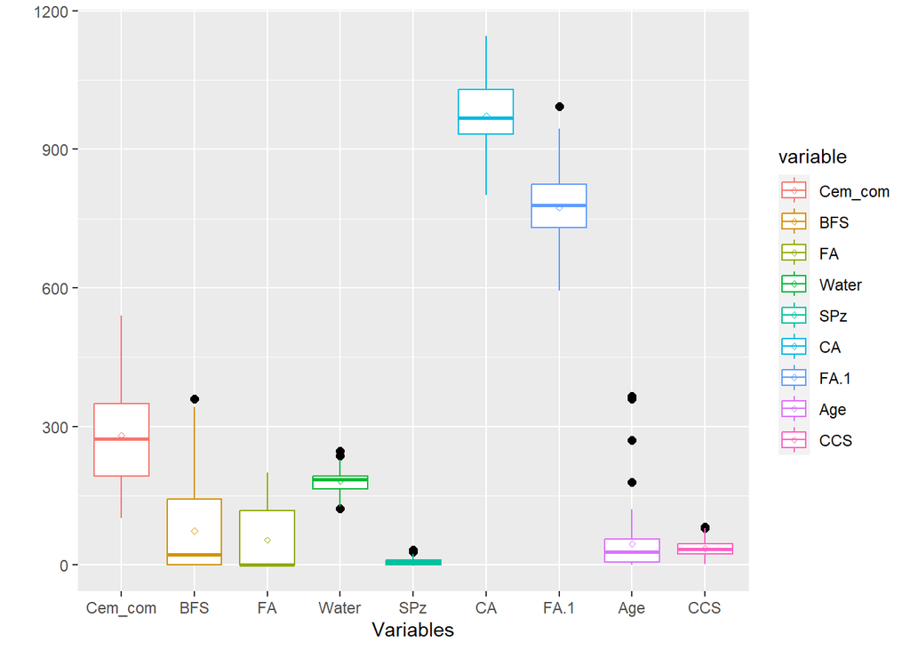

```r
ggplot(data=data_long, mapping = aes(x=variable, y= value, color = variable)) +
  geom_boxplot(outlier.colour="black", outlier.shape=16,
               outlier.size=2, notch=FALSE) +
  stat_summary(fun=mean, geom="point", shape=23, size=1) +
  scale_fill_manual(values=c("#999999", "#E69F00", "#56B4E9"))+
  labs(x="Variables",y="")
```

```r
T.min <- quantile(Y, 0.25) - 1.5*IQR(Y)
T.max <- quantile(Y, 0.75) + 1.5*IQR(Y)
head(Y[which(Y > T.min & Y < T.max)])
```

```
## [1] 61.89 40.27 41.05 44.30 47.03 43.70
```

```r
length(Y[which(Y > T.min & Y < T.max)])
```

```
## [1] 1026
```

```r
Y[which(Y < T.min | Y > T.max)]
```

```
## [1] 79.99 80.20 82.60 81.75
```

```r
rel_outlier <- function(a){
  #boxplot(Y, main = "Boxplot")
  T.min <- quantile(a, 0.25) - 1.5*IQR(a)
  T.max <- quantile(a, 0.75) + 1.5*IQR(a)
  #print(a[which(a > T.min & a < T.max)])
  return(a[which(a < T.min | a > T.max)])
}
```

## 3.2.2. Xác định tất cả các dữ liệu ngoại lai ở các biến khỏi tập dữ liệu

```r
colnames(data)
```

```
## [1] "Cem_com" "BFS"     "FA"      "Water"   "SPz"     "CA"      "FA.1"
## [8] "Age"     "CCS"
```

```r
# Loc tat ca du lieu ngoai lai tu tap du lieu
Y_rel_out = rel_outlier(Y)
Y_rel_out
```

```
## [1] 79.99 80.20 82.60 81.75
```

```r
X1_rel_out = rel_outlier(X1)
X1_rel_out
```

```
## numeric(0)
```

```r
X2_rel_out = rel_outlier(X2)
X2_rel_out
```

```
## [1] 359.4 359.4
```

```r
X4_rel_out = rel_outlier(X4)
X4_rel_out
```

```
## [1] 121.8 121.8 121.8 121.8 121.8 237.0 247.0 246.9 236.7
```

```r
X5_rel_out = rel_outlier(X5)
X5_rel_out
```

```
##  [1] 32.2 28.2 32.2 28.2 32.2 28.2 32.2 28.2 32.2 28.2
```

```r
X7_rel_out = rel_outlier(X7)
X7_rel_out
```

```
## [1] 992.6 992.6 992.6 992.6 992.6
```

```r
X8_rel_out = rel_outlier(X8)
X8_rel_out
```

```
##  [1] 270 365 360 365 270 365 180 180 180 365 270 270 180 365 365 180 270 365 270
## [20] 180 365 365 180 180 180 180 365 180 270 270 270 180 270 360 180 365 180 365
## [39] 180 360 180 365 180 365 180 270 180 180 360 180 360 180 180 180 270 180 360
## [58] 270 180
```

## 3.2.3. Vẽ biểu đồ phân tán, đánh dấu các biến ngoại lai

```r
##############################################################################
##############################################################################
#Plot all outlier in scatter chart Y~X2 (CCS ~ BFS)
data2_out_r_in = data %>%
  add_column(class = NA)
for(j in X2_rel_out){
  data2_out_r_in["class"][data2_out_r_in["BFS"] == j] = "out"
}

data2_out_r_in %>%
  filter(data2_out_r_in["class"] != "not_out")
```

```
##   Cem_com   BFS FA Water SPz    CA  FA.1 Age   CCS class
## 1   239.6 359.4  0 185.7   0 941.6 664.3   7 25.42   out
## 2   239.6 359.4  0 185.7   0 941.6 664.3  28 39.44   out
```

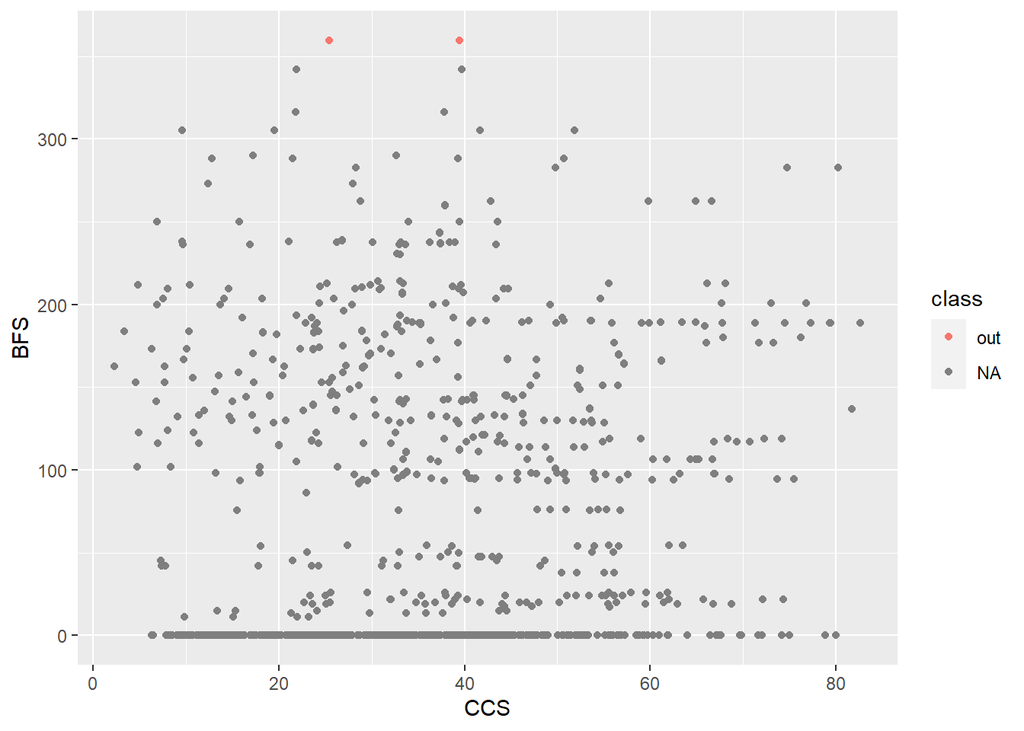

```r
#Scatter chart to show the outliers
ggplot(data = data2_out_r_in) +
  geom_point(mapping = aes(x = CCS, y = BFS, color = class), shape = 19)
```

```r
##############################################################################
##############################################################################
#Ve bieu do phan tan Ox: CCS, Oy:Water
data2_out_r_in = data %>%
  add_column(class = NA)
for(i in X4_rel_out){
  data2_out_r_in["class"][data2_out_r_in["Water"] == i] = "out"
}

data2_out_r_in %>%
  filter(data2_out_r_in["class"] != "not_out")
```

```
##   Cem_com   BFS    FA Water SPz     CA  FA.1 Age   CCS class
## 1   168.0  42.1 163.8 121.8 5.7 1058.7 780.1   3  7.75   out
## 2   168.0  42.1 163.8 121.8 5.7 1058.7 780.1  14 17.82   out
## 3   168.0  42.1 163.8 121.8 5.7 1058.7 780.1  28 24.24   out
## 4   168.0  42.1 163.8 121.8 5.7 1058.7 780.1  56 32.85   out
## 5   168.0  42.1 163.8 121.8 5.7 1058.7 780.1 100 39.23   out
## 6   140.0 164.0 128.0 237.0 6.0  869.0 656.0  28 35.23   out
## 7   237.0  92.0  71.0 247.0 6.0  853.0 695.0  28 28.63   out
## 8   236.9  91.7  71.5 246.9 6.0  852.9 695.4  28 28.63   out
## 9   139.7 163.9 127.7 236.7 5.8  868.6 655.6  28 35.23   out
```

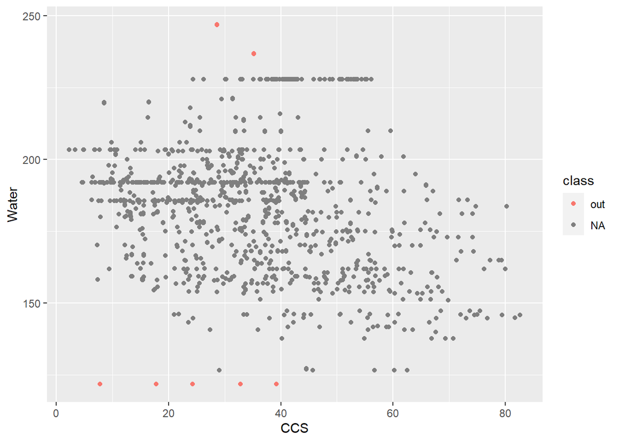

```r
#Scatter chart to show the outliers
ggplot(data = data2_out_r_in) +
  geom_point(mapping = aes(x = CCS, y = Water, color = class), shape = 19)
```

```r
##############################################################################
##############################################################################
#Plot all outlier in scatter chart Y~X5 (CCS ~ SPz)
data2_out_r_in = data %>%
  add_column(class = NA)
for(j in X5_rel_out){
  data2_out_r_in["class"][data2_out_r_in["SPz"] == j] = "out"
}

data2_out_r_in %>%
  filter(data2_out_r_in["class"] != "not_out")
```

```
##    Cem_com   BFS FA Water  SPz    CA  FA.1 Age  CCS class
## 1    469.0 117.2  0 137.8 32.2 852.1 840.5   3 40.2   out
## 2    531.3   0.0  0 141.8 28.2 852.1 893.7   3 41.3   out
## 3    469.0 117.2  0 137.8 32.2 852.1 840.5   7 54.9   out
## 4    531.3   0.0  0 141.8 28.2 852.1 893.7   7 46.9   out
## 5    469.0 117.2  0 137.8 32.2 852.1 840.5  28 66.9   out
## 6    531.3   0.0  0 141.8 28.2 852.1 893.7  28 56.4   out
## 7    469.0 117.2  0 137.8 32.2 852.1 840.5  56 69.3   out
## 8    531.3   0.0  0 141.8 28.2 852.1 893.7  56 58.8   out
## 9    469.0 117.2  0 137.8 32.2 852.1 840.5  91 70.7   out
## 10   531.3   0.0  0 141.8 28.2 852.1 893.7  91 59.2   out
```

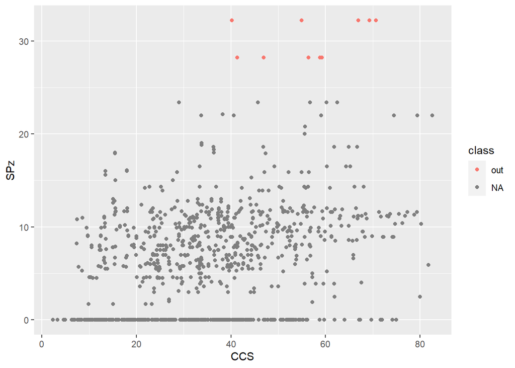

```r
#Scatter chart to show the outliers
ggplot(data = data2_out_r_in) +
  geom_point(mapping = aes(x = CCS, y = SPz, color = class), shape = 19)
```

```r
##############################################################################
##############################################################################
#Plot all outlier in scatter chart Y~X7 (CCS ~ SPz)
data2_out_r_in = data %>%
  add_column(class = NA)
for(j in X7_rel_out){
  data2_out_r_in["class"][data2_out_r_in["FA.1"] == j] = "out"
}

data2_out_r_in %>%
  filter(data2_out_r_in["class"] != "not_out")
```

```
##   Cem_com  BFS FA Water  SPz    CA  FA.1 Age  CCS class
## 1     375 93.8  0 126.6 23.4 852.1 992.6   3 29.0   out
## 2     375 93.8  0 126.6 23.4 852.1 992.6   7 45.7   out
## 3     375 93.8  0 126.6 23.4 852.1 992.6  28 56.7   out
## 4     375 93.8  0 126.6 23.4 852.1 992.6  56 60.2   out
## 5     375 93.8  0 126.6 23.4 852.1 992.6  91 62.5   out
```

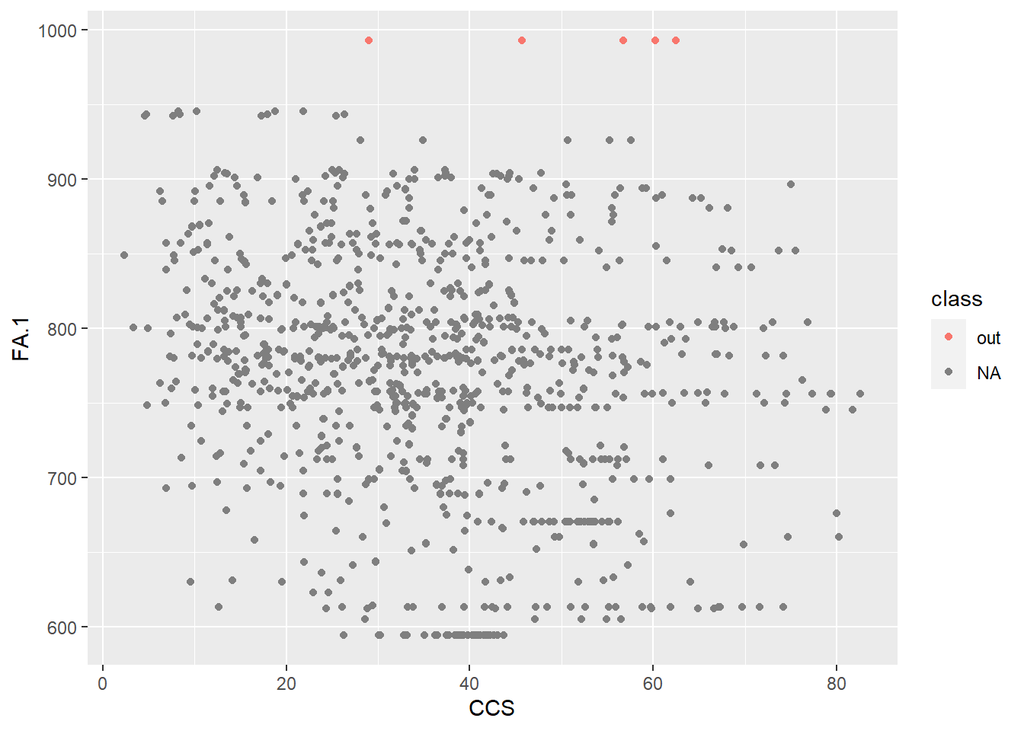

```r
#Scatter chart to show the outliers
ggplot(data = data2_out_r_in) +
  geom_point(mapping = aes(x = CCS, y = FA.1, color = class), shape = 19)
```

```r
##############################################################################
##############################################################################
#Plot all outlier in scatter chart Y~X8 (CCS ~ SPz)
data2_out_r_in = data %>%
  add_column(class = NA)
for(j in X8_rel_out){
  data2_out_r_in["class"][data2_out_r_in["Age"] == j] = "out"
}

data2_out_r_in %>%
  filter(data2_out_r_in["class"] != "not_out")
```

```
##    Cem_com   BFS FA Water SPz     CA  FA.1 Age   CCS class
## 1    332.5 142.5  0   228   0  932.0 594.0 270 40.27   out
## 2    332.5 142.5  0   228   0  932.0 594.0 365 41.05   out
## 3    198.6 132.4  0   192   0  978.4 825.5 360 44.30   out
## 4    380.0  95.0  0   228   0  932.0 594.0 365 43.70   out
## 5    427.5  47.5  0   228   0  932.0 594.0 270 43.01   out
## 6    342.0  38.0  0   228   0  932.0 670.0 365 56.14   out
## 7    475.0   0.0  0   228   0  932.0 594.0 180 42.62   out
## 8    427.5  47.5  0   228   0  932.0 594.0 180 41.84   out
## 9    139.6 209.4  0   192   0 1047.0 806.9 180 44.21   out
## 10   380.0   0.0  0   228   0  932.0 670.0 365 52.52   out
## 11   380.0   0.0  0   228   0  932.0 670.0 270 53.30   out
## 12   380.0  95.0  0   228   0  932.0 594.0 270 41.15   out
## 13   342.0  38.0  0   228   0  932.0 670.0 180 52.12   out
## 14   304.0  76.0  0   228   0  932.0 670.0 365 55.26   out
```

[output cut: 45 more lines]

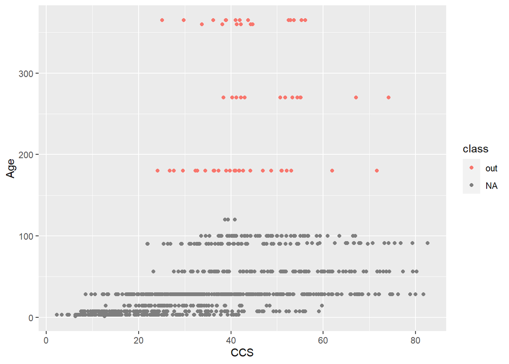

```r
#Scatter chart to show the outliers
ggplot(data = data2_out_r_in) +
  geom_point(mapping = aes(x = CCS, y = Age, color = class), shape = 19)
```

## 3.2.4 Tạo data1 không chứa các ngoại lai

```r
#Tao data1 khong chua cac ngoai lai
data1 = data |>
  filter(!(data$BFS %in% X2_rel_out),
         !(data$Water %in% X4_rel_out),
         !(data$SPz %in% X5_rel_out),
         !(data$FA.1 %in% X7_rel_out),
         !(data$Age %in% X8_rel_out))
```

# 3.3. Chuẩn bị tập train và tập valid

Để áp dụng các mô hình hồi quy cho các biến, chúng tôi đã chọn ra $80%$ điểm dữ liệu bất kì trong tập dữ liệu data1 và được lưu vào tập train. Dữ liệu còn lại dùng để kiểm tra tính chính xác của các mô hình được xây dựng.

```r
#Chuan bi tap train va tap valid
set.seed(1)
constant_balance = as.integer(0.8 * length(data1$CCS))
cso_hang_cement = sample.int(length(data1$CCS),constant_balance)

train = data1[cso_hang_cement,]
head(train)
```

```
##     Cem_com   BFS    FA Water  SPz     CA  FA.1 Age   CCS
## 836   145.0   0.0 179.0 202.0  8.0  824.0 869.0  28 10.54
## 679   281.0   0.0   0.0 186.0  0.0 1104.0 774.0   7 14.50
## 129   362.6 189.0   0.0 164.9 11.6  944.7 755.8  91 79.30
## 930   355.9   0.0 141.6 193.3 11.0  801.4 778.4  28 40.87
## 509   158.8 238.2   0.0 185.7  0.0 1040.6 734.3  28 21.07
## 471   359.0  19.0 141.0 154.0 10.9  942.0 801.0  28 59.49
```

```r
length(train$CCS)
```

```
## [1] 756
```

```r
valid = data1[-cso_hang_cement,]
tail(valid)
```

```
##     Cem_com   BFS    FA Water  SPz    CA  FA.1 Age   CCS
## 912   158.6 148.9 116.0 175.1 15.0 953.3 719.7  28 27.68
## 921   279.8 128.9 100.4 172.4  9.5 825.1 804.9  28 52.83
## 922   252.1  97.1  75.6 193.8  8.3 835.5 821.4  28 33.40
## 926   298.1   0.0 107.0 186.4  6.1 879.0 815.2  28 42.64
## 936   288.4 121.0   0.0 177.4  7.0 907.9 829.5  28 42.14
## 937   298.2   0.0 107.0 209.7 11.1 879.6 744.2  28 31.88
```

```r
length(valid$CCS)
```

```
## [1] 189
```

# 3.3 Xây dựng mô hình hồi quy

## 3.3.1. Xây dựng mô hình hồi quy đơn và hồi quy đa thức

```r
# Mo hinh hoi quy don
# Tinh correlation giua cac bien
Y.new = train$CCS
length(Y.new)
```

```
## [1] 756
```

```r
cor(train)
```

```
##             Cem_com          BFS           FA        Water         SPz
## Cem_com  1.00000000 -0.264555716 -0.384639726 -0.077980613  0.03775151
## BFS     -0.26455572  1.000000000 -0.346744867  0.095952337  0.03496834
## FA      -0.38463973 -0.346744867  1.000000000 -0.243904283  0.45162732
## Water   -0.07798061  0.095952337 -0.243904283  1.000000000 -0.64033641
## SPz      0.03775151  0.034968335  0.451627319 -0.640336408  1.00000000
## CA      -0.12732884 -0.279287131 -0.020269633 -0.232776383 -0.21263889
## FA.1    -0.22059832 -0.282956681  0.050053339 -0.352980499  0.11457941
## Age     -0.02697343  0.004343866  0.006803274  0.001825466  0.03201993
## CCS      0.46476055  0.167131988 -0.096049810 -0.357182481  0.38257678
##                  CA        FA.1          Age         CCS
## Cem_com -0.12732884 -0.22059832 -0.026973425  0.46476055
## BFS     -0.27928713 -0.28295668  0.004343866  0.16713199
## FA      -0.02026963  0.05005334  0.006803274 -0.09604981
## Water   -0.23277638 -0.35298050  0.001825466 -0.35718248
## SPz     -0.21263889  0.11457941  0.032019927  0.38257678
## CA       1.00000000 -0.17515664  0.012315080 -0.14730159
## FA.1    -0.17515664  1.00000000  0.033914507 -0.14815281
## Age      0.01231508  0.03391451  1.000000000  0.53450662
## CCS     -0.14730159 -0.14815281  0.534506621  1.00000000
```

```r
cor(Y.new, train$Cem_com)
```

```
## [1] 0.4647605
```

```r
colnames(train)
```

```
## [1] "Cem_com" "BFS"     "FA"      "Water"   "SPz"     "CA"      "FA.1"
## [8] "Age"     "CCS"
```

```r
# Mo hinh hoi quy don
lres <- lm(CCS~Cem_com, data = train)
summary(lres)
```

```
##
## Call:
## lm(formula = CCS ~ Cem_com, data = train)
##
## Residuals:
##     Min      1Q  Median      3Q     Max
## -36.941 -11.732  -0.972   9.697  43.861
##
## Coefficients:
##              Estimate Std. Error t value Pr(>|t|)
## (Intercept) 13.938391   1.548646    9.00   <2e-16 ***
## Cem_com      0.076034   0.005275   14.41   <2e-16 ***
## ---
## Signif. codes:  0 '***' 0.001 '**' 0.01 '*' 0.05 '.' 0.1 ' ' 1
##
## Residual standard error: 14.69 on 754 degrees of freedom
## Multiple R-squared:  0.216,  Adjusted R-squared:  0.215
## F-statistic: 207.7 on 1 and 754 DF,  p-value: < 2.2e-16
```

```r
shapiro.test(rstandard(lres))
```

```
##
##  Shapiro-Wilk normality test
##
## data:  rstandard(lres)
## W = 0.98611, p-value = 1.37e-06
```

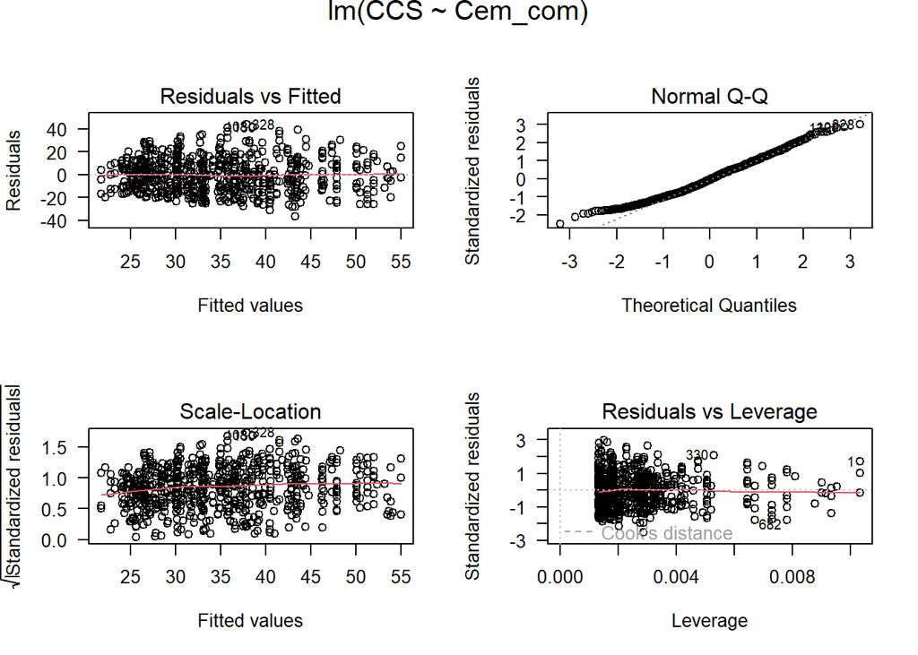

```r
opar <- par(mfrow = c(2,2), oma = c(0, 0, 1.1, 0))
plot(lres, las = 1)
```

```r
#####################################################
# t_score
gamma = 0.05
n = length(train$CCS)
t_score1=qt(gamma/2, df=n-2, lower.tail=FALSE); t_score1
```

```
## [1] 1.963115
```

```r
#####################################################
# Mo hinh hoi quy da thuc
x_new = cbind(train$Cem_com, train$Cem_com^2,train$Cem_com^3)
poly_res = lm(train$CCS~x_new)
summary(poly_res)
```

```
##
## Call:
## lm(formula = train$CCS ~ x_new)
##
## Residuals:
##     Min      1Q  Median      3Q     Max
## -36.802 -11.581  -1.026   9.738  43.789
##
## Coefficients:
##               Estimate Std. Error t value Pr(>|t|)
## (Intercept)  1.046e+01  1.141e+01   0.917    0.359
## x_new1       1.130e-01  1.253e-01   0.902    0.367
## x_new2      -1.180e-04  4.239e-04  -0.278    0.781
## x_new3       1.156e-07  4.469e-07   0.259    0.796
##
## Residual standard error: 14.71 on 752 degrees of freedom
## Multiple R-squared:  0.2161, Adjusted R-squared:  0.213
## F-statistic: 69.11 on 3 and 752 DF,  p-value: < 2.2e-16
```

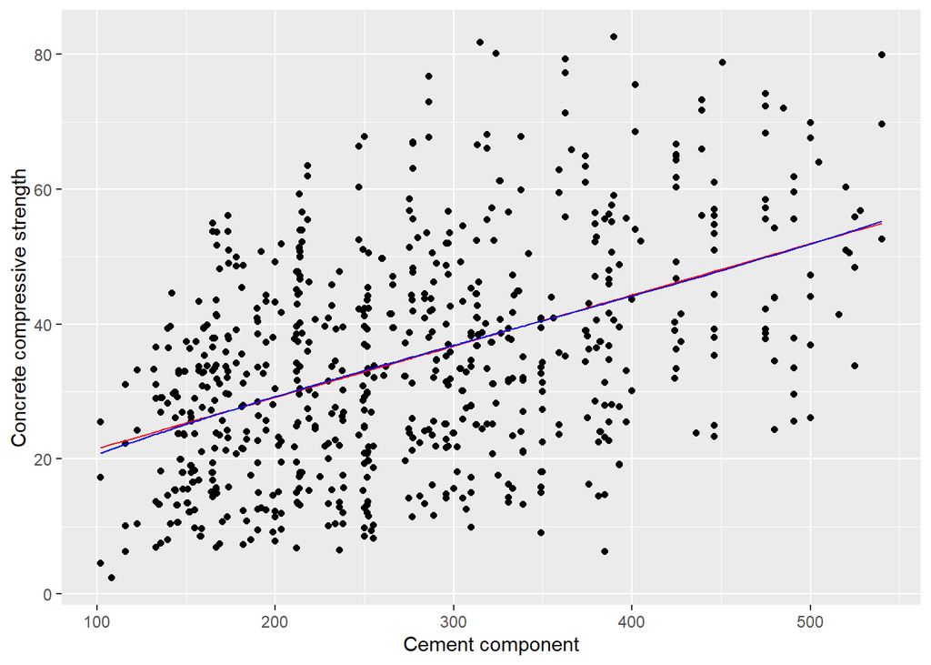

```r
ggplot() + geom_point(aes(x = train$Cem_com,y = train$CCS)) +
  geom_line(aes(x = train$Cem_com,y = lres$fit),color = "red") +
  geom_line(aes(x = train$Cem_com,y = poly_res$fit),color = "blue") +
  labs(x = "Cement component", y = "Concrete compressive strength")
```

## 3.3.2. Xây dựng mô hình hồi quy có trọng số (weighted least squares)

Tuy nhiên, khi quan sát phân tích phần dư của mô hồi quy tuyến tính, chúng tôi cảm nhận phần dư có phương sai thay đổi nên tiến hành kiểm định Breusch-Pagan và nhận được kết quả bác bỏ $H_0$: Phương sai không đổi”. Vì thế chúng tôi tiếp tục tiến hành xây dựng mô hình hồi quy có trọng số.

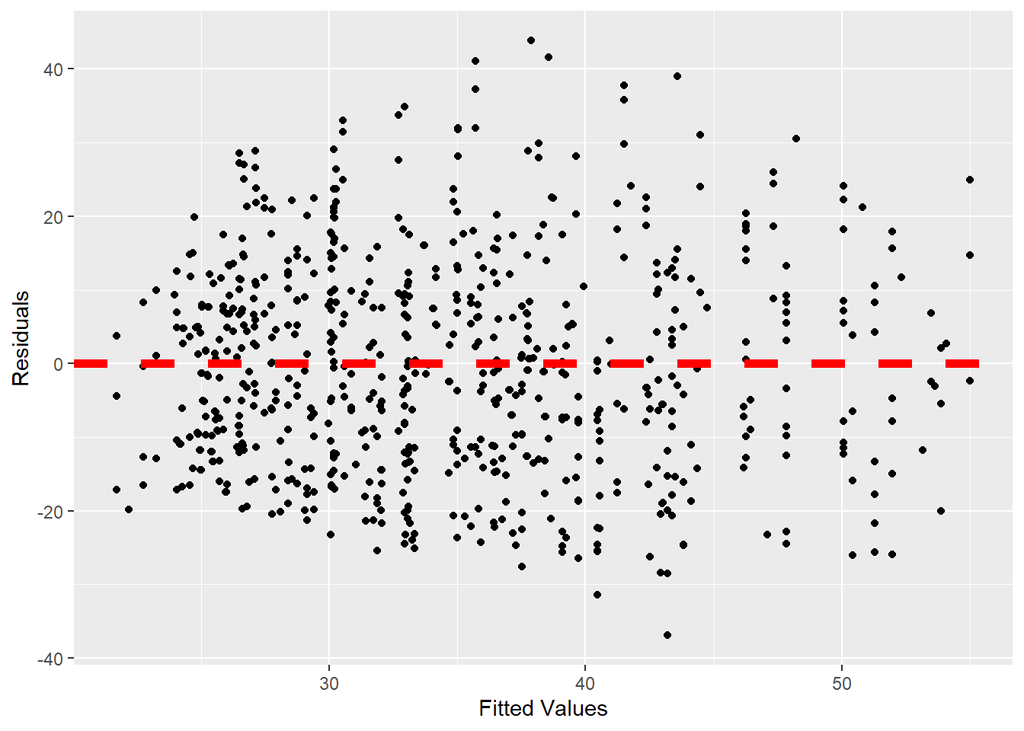

```r
#####################################################
#create residual vs. fitted plot
#add a horizontal line at 0
ggplot() + geom_point(aes(x = fitted(lres),y = resid(lres))) +
  geom_hline(yintercept=0, linetype="dashed", color = "red", size = 2)+
  labs(x = "Fitted Values", y = "Residuals")
```

```r
#perform Breusch-Pagan test
bptest(lres)
```

```
##
##  studentized Breusch-Pagan test
##
## data:  lres
## BP = 17.729, df = 1, p-value = 2.548e-05
```

```r
# Co hien tuong phuong sai thay doi
#define weights to use
wt <- 1 / lm(abs(lres$residuals) ~ lres$fitted.values)$fitted.values^2

#perform weighted least squares regression
wls_model <- lm(CCS ~ Cem_com, data = train, weights=wt)

#view summary of model
summary(wls_model)
```

```
##
## Call:
## lm(formula = CCS ~ Cem_com, data = train, weights = wt)
##
## Weighted Residuals:
##     Min      1Q  Median      3Q     Max
## -2.7677 -0.9798 -0.0777  0.8246  3.4937
##
## Coefficients:
##              Estimate Std. Error t value Pr(>|t|)
## (Intercept) 13.862480   1.494089   9.278   <2e-16 ***
## Cem_com      0.076315   0.005442  14.022   <2e-16 ***
## ---
## Signif. codes:  0 '***' 0.001 '**' 0.01 '*' 0.05 '.' 0.1 ' ' 1
##
## Residual standard error: 1.207 on 754 degrees of freedom
## Multiple R-squared:  0.2068, Adjusted R-squared:  0.2058
## F-statistic: 196.6 on 1 and 754 DF,  p-value: < 2.2e-16
```

```r
shapiro.test(rstandard(wls_model))
```

```
##
##  Shapiro-Wilk normality test
##
## data:  rstandard(wls_model)
## W = 0.98214, p-value = 5.629e-08
```

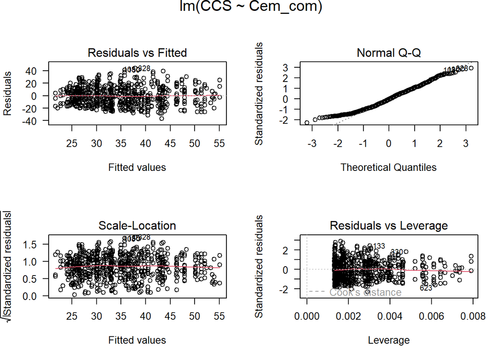

```r
opar <- par(mfrow = c(2,2), oma = c(0, 0, 1.1, 0))
plot(wls_model, las = 1)
```

## 3.3.3. Xây dựng mô hình hồi quy bội cho tập train

Các biến đầu vào trong tập dữ liệu là các thành phần tham gia vào quá trình sản suất betông. Do đó, chúng tôi giả định tất cả các biến đầu vào đều có mối quan hệ tuyến tính với biến đầu ra và áp dụng mô hình hồi quy bội (mô hình $\verb|Model_8v|$) cho biến đầu ra với toàn bộ các biến khác trong tập dữ liệu.

```r
# Mo hinh day du cac bien
Model_8v <- lm(Y.new ~., data = train[,1:8])
summary(Model_8v)
```

```
##
## Call:
## lm(formula = Y.new ~ ., data = train[, 1:8])
##
## Residuals:
##     Min      1Q  Median      3Q     Max
## -22.644  -4.876  -0.283   5.185  34.025
##
## Coefficients:
##              Estimate Std. Error t value Pr(>|t|)
## (Intercept) 28.490217  24.875673   1.145   0.2524
## Cem_com      0.104807   0.007722  13.573  < 2e-16 ***
## BFS          0.080875   0.009164   8.825  < 2e-16 ***
## FA           0.050770   0.011398   4.454 9.70e-06 ***
## Water       -0.226783   0.038933  -5.825 8.49e-09 ***
## SPz          0.226991   0.095218   2.384   0.0174 *
## CA           0.000461   0.008785   0.052   0.9582
## FA.1        -0.003468   0.009863  -0.352   0.7252
## Age          0.312408   0.010206  30.611  < 2e-16 ***
## ---
## Signif. codes:  0 '***' 0.001 '**' 0.01 '*' 0.05 '.' 0.1 ' ' 1
##
## Residual standard error: 8.096 on 747 degrees of freedom
## Multiple R-squared:  0.7641, Adjusted R-squared:  0.7616
## F-statistic: 302.5 on 8 and 747 DF,  p-value: < 2.2e-16
```

```r
#Tim chi so VIF cho tung bien doc lap
VIF(Model_8v)
```

```
##  Cem_com      BFS       FA    Water      SPz       CA     FA.1      Age
## 7.056209 7.207150 6.193798 6.210680 3.070807 5.345264 6.002041 1.012114
```

```r
# Tinh correlation giua cac bien
cor(train)
```

```
##             Cem_com          BFS           FA        Water         SPz
## Cem_com  1.00000000 -0.264555716 -0.384639726 -0.077980613  0.03775151
## BFS     -0.26455572  1.000000000 -0.346744867  0.095952337  0.03496834
## FA      -0.38463973 -0.346744867  1.000000000 -0.243904283  0.45162732
## Water   -0.07798061  0.095952337 -0.243904283  1.000000000 -0.64033641
## SPz      0.03775151  0.034968335  0.451627319 -0.640336408  1.00000000
## CA      -0.12732884 -0.279287131 -0.020269633 -0.232776383 -0.21263889
## FA.1    -0.22059832 -0.282956681  0.050053339 -0.352980499  0.11457941
## Age     -0.02697343  0.004343866  0.006803274  0.001825466  0.03201993
## CCS      0.46476055  0.167131988 -0.096049810 -0.357182481  0.38257678
##                  CA        FA.1          Age         CCS
## Cem_com -0.12732884 -0.22059832 -0.026973425  0.46476055
## BFS     -0.27928713 -0.28295668  0.004343866  0.16713199
## FA      -0.02026963  0.05005334  0.006803274 -0.09604981
## Water   -0.23277638 -0.35298050  0.001825466 -0.35718248
## SPz     -0.21263889  0.11457941  0.032019927  0.38257678
## CA       1.00000000 -0.17515664  0.012315080 -0.14730159
## FA.1    -0.17515664  1.00000000  0.033914507 -0.14815281
## Age      0.01231508  0.03391451  1.000000000  0.53450662
## CCS     -0.14730159 -0.14815281  0.534506621  1.00000000
```

```r
cor(Y.new, train$BFS)
```

```
## [1] 0.167132
```

```r
cor(Y.new, train$Cem_com)
```

```
## [1] 0.4647605
```

```r
cor(train$Cem_com, train$BFS)
```

```
## [1] -0.2645557
```

```r
# Su dung thu vien MASS de dung lenh stepAIC
step.model <- stepAIC(Model_8v, direction = "both", trace = TRUE)
```

```
## Start:  AIC=3171.19
## Y.new ~ Cem_com + BFS + FA + Water + SPz + CA + FA.1 + Age
##
##           Df Sum of Sq    RSS    AIC
## - CA       1         0  48968 3169.2
## - FA.1     1         8  48976 3169.3
## <none>                  48968 3171.2
## - SPz      1       373  49341 3174.9
## - FA       1      1301  50269 3189.0
## - Water    1      2224  51192 3202.8
## - BFS      1      5105  54073 3244.2
## - Cem_com  1     12076  61044 3335.8
## - Age      1     61424 110392 3783.7
##
## Step:  AIC=3169.19
## Y.new ~ Cem_com + BFS + FA + Water + SPz + FA.1 + Age
##
##           Df Sum of Sq    RSS    AIC
## - FA.1     1        34  49002 3167.7
## <none>                  48968 3169.2
## + CA       1         0  48968 3171.2
## - SPz      1       423  49391 3173.7
## - FA       1      2440  51408 3203.9
## - Water    1      6942  55910 3267.4
## - BFS      1     14346  63315 3361.4
## - Cem_com  1     32572  81540 3552.7
## - Age      1     61898 110866 3785.0
##
## Step:  AIC=3167.71
## Y.new ~ Cem_com + BFS + FA + Water + SPz + Age
##
##           Df Sum of Sq    RSS    AIC
## <none>                  49002 3167.7
## + FA.1     1        34  48968 3169.2
## + CA       1        26  48976 3169.3
## - SPz      1       395  49397 3171.8
## - FA       1      3396  52398 3216.4
## - Water    1      7482  56484 3273.1
## - BFS      1     21296  70298 3438.5
## - Cem_com  1     48216  97218 3683.6
## - Age      1     61864 110866 3783.0
```

```r
summary(step.model)
```

```
##
## Call:
## lm(formula = Y.new ~ Cem_com + BFS + FA + Water + SPz + Age,
##     data = train[, 1:8])
##
## Residuals:
##     Min      1Q  Median      3Q     Max
## -22.510  -4.883  -0.366   5.191  34.300
##
## Coefficients:
##              Estimate Std. Error t value Pr(>|t|)
## (Intercept) 24.964687   4.146036   6.021 2.71e-09 ***
## Cem_com      0.106337   0.003917  27.147  < 2e-16 ***
## BFS          0.082601   0.004578  18.042  < 2e-16 ***
## FA           0.053038   0.007362   7.205 1.42e-12 ***
## Water       -0.223013   0.020854 -10.694  < 2e-16 ***
## SPz          0.214447   0.087291   2.457   0.0142 *
## Age          0.312285   0.010155  30.750  < 2e-16 ***
## ---
## Signif. codes:  0 '***' 0.001 '**' 0.01 '*' 0.05 '.' 0.1 ' ' 1
##
## Residual standard error: 8.088 on 749 degrees of freedom
## Multiple R-squared:  0.764,  Adjusted R-squared:  0.7621
## F-statistic: 404.1 on 6 and 749 DF,  p-value: < 2.2e-16
```

```r
Cement_str = step.model
summary(Cement_str)
```

```
##
## Call:
## lm(formula = Y.new ~ Cem_com + BFS + FA + Water + SPz + Age,
##     data = train[, 1:8])
##
## Residuals:
##     Min      1Q  Median      3Q     Max
## -22.510  -4.883  -0.366   5.191  34.300
##
## Coefficients:
##              Estimate Std. Error t value Pr(>|t|)
## (Intercept) 24.964687   4.146036   6.021 2.71e-09 ***
## Cem_com      0.106337   0.003917  27.147  < 2e-16 ***
## BFS          0.082601   0.004578  18.042  < 2e-16 ***
## FA           0.053038   0.007362   7.205 1.42e-12 ***
## Water       -0.223013   0.020854 -10.694  < 2e-16 ***
## SPz          0.214447   0.087291   2.457   0.0142 *
## Age          0.312285   0.010155  30.750  < 2e-16 ***
## ---
## Signif. codes:  0 '***' 0.001 '**' 0.01 '*' 0.05 '.' 0.1 ' ' 1
##
## Residual standard error: 8.088 on 749 degrees of freedom
## Multiple R-squared:  0.764,  Adjusted R-squared:  0.7621
## F-statistic: 404.1 on 6 and 749 DF,  p-value: < 2.2e-16
```

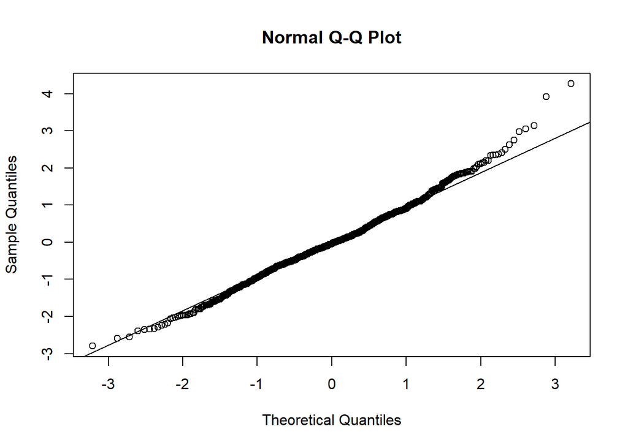

```r
qqnorm(rstandard(Cement_str))
qqline(rstandard(Cement_str))
```

```r
# Kiem tra phan du co phan phoi chuan bang lenh shapiro.test
shapiro.test(rstandard(Cement_str))
```

```
##
##  Shapiro-Wilk normality test
##
## data:  rstandard(Cement_str)
## W = 0.99236, p-value = 0.000625
```

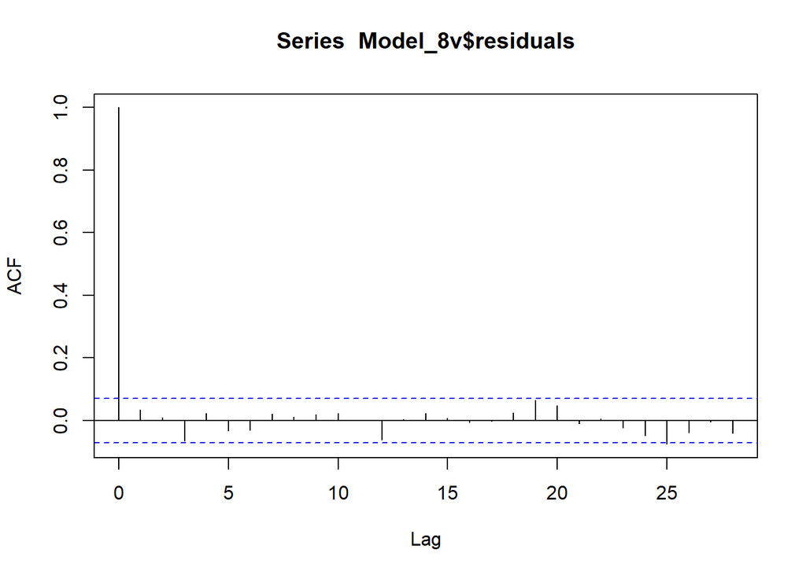

```r
################################################################################
acf(Model_8v$residuals, type = "correlation")
#Kiem tra tinh tu tuong quan
acf(Model_8v$residuals, type = "correlation")
```

```r
dwt(Model_8v) # Khong co co so de bac bo H0: residual is not autocorrelated
```

```
##  lag Autocorrelation D-W Statistic p-value
##    1      0.03395901      1.924072   0.322
##  Alternative hypothesis: rho != 0
```

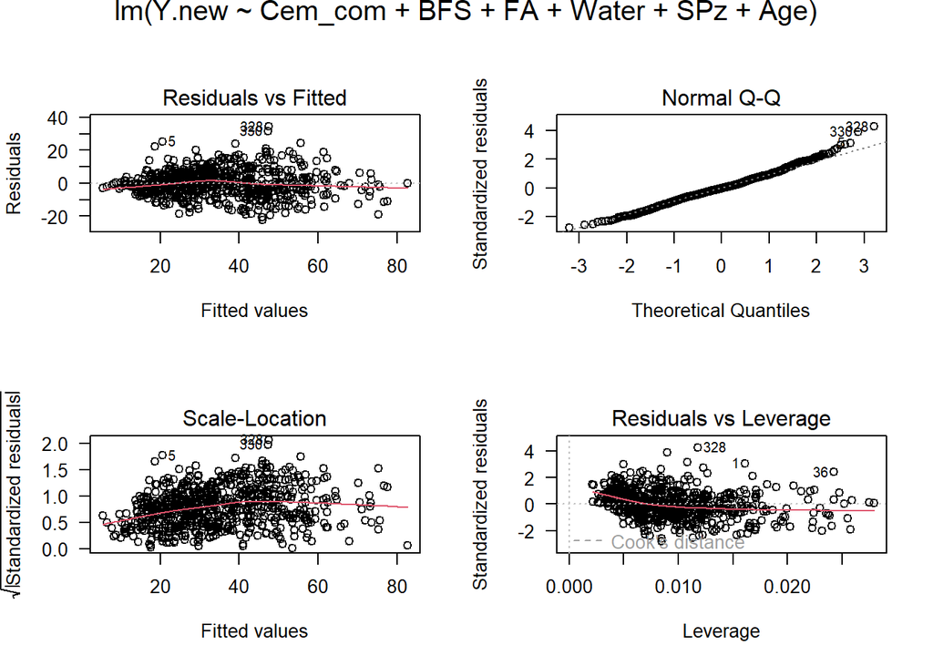

```r
################################################################################

# Phan tich phan du (Residual Analysis)
opar <- par(mfrow = c(2,2), oma = c(0, 0, 1.1, 0))
plot(Cement_str, las = 1)
```

Với mô hình hồi quy bội vừa tìm được, các biến được sử dụng là $\verb|Cem_com|$, $\verb|BFS|$, $\verb|FA|$, $\verb|Water|$, $\verb|SPz|$, $\verb|Age|$. Mô hình cũng tăng khả năng giải thích tập dữ liệu lên đến $76\%$ tập dữ liệu ($\verb|Multiple R-squared|=0.764$). Ngoài ra, khi phân tích phần dư, dễ thấy phân dư có trung bình là $0$, có phương sai không đổi nhưng không tuần theo phân phối chuẩn(dựa trên kiếm định Shapiro-Wilk test) và không tự tương quan theo kiểm định Durbin-Watson

Chúng tôi áp dụng thêm hồi quy “chắc” (Robust Regression) - $\verb|Cement_str_robust|$ cho tập $\verb|train|$ khi quan sát thấy các $\verb|influential cases|$(giá trị ngoại biên) và $\verb|Cement_str_robust_nrout|$ cho tập dữ liệu $\verb|train_no_rel|$, $\verb|valid_no_rel|$ được chia ra từ tập dữ liệu không bỏ ngoại lai ban đầu với các biến đầu vào được xác định như mô hình hồi quy đa biến $\verb|Cement_str|$ và nhận được các kết quả tương đối khả quan.

## 3.3.4. Xây dựng mô hình Robust Regression cho tập train

```r
Cement_str_robust <- lmrob(CCS ~ Cem_com + BFS+ FA + Water + SPz + Age, data = train)
summary(Cement_str_robust)
```

```
##
## Call:
## lmrob(formula = CCS ~ Cem_com + BFS + FA + Water + SPz + Age, data = train)
##  \--> method = "MM"
## Residuals:
##        Min         1Q     Median         3Q        Max
## -22.489039  -4.741032  -0.008123   5.287022  35.166555
##
## Coefficients:
##              Estimate Std. Error t value Pr(>|t|)
## (Intercept) 21.616489   4.455201   4.852 1.49e-06 ***
## Cem_com      0.106710   0.004345  24.561  < 2e-16 ***
## BFS          0.082058   0.005164  15.892  < 2e-16 ***
## FA           0.054420   0.007220   7.537 1.39e-13 ***
## Water       -0.207457   0.023073  -8.991  < 2e-16 ***
## SPz          0.262359   0.090929   2.885  0.00402 **
## Age          0.308744   0.010717  28.809  < 2e-16 ***
## ---
## Signif. codes:  0 '***' 0.001 '**' 0.01 '*' 0.05 '.' 0.1 ' ' 1
##
## Robust residual standard error: 7.22
## Multiple R-squared:  0.7821, Adjusted R-squared:  0.7804
## Convergence in 13 IRWLS iterations
##
## Robustness weights:
##  observation 535 is an outlier with |weight| = 0 ( < 0.00013);
##  73 weights are ~= 1. The remaining 682 ones are summarized as
##    Min. 1st Qu.  Median    Mean 3rd Qu.    Max.
## 0.01514 0.85480 0.94540 0.88890 0.98620 0.99890
## Algorithmic parameters:
##        tuning.chi                bb        tuning.psi        refine.tol
##         1.548e+00         5.000e-01         4.685e+00         1.000e-07
##           rel.tol         scale.tol         solve.tol       eps.outlier
##         1.000e-07         1.000e-10         1.000e-07         1.323e-04
##             eps.x warn.limit.reject warn.limit.meanrw
##         9.823e-10         5.000e-01         5.000e-01
##      nResample         max.it       best.r.s       k.fast.s          k.max
##            500             50              2              1            200
##    maxit.scale      trace.lev            mts     compute.rd fast.s.large.n
##            200              0           1000              0           2000
##                   psi           subsampling                   cov
##            "bisquare"         "nonsingular"         ".vcov.avar1"
## compute.outlier.stats
##                  "SM"
## seed : int(0)
```

```r
cbind(coef(Cement_str_robust),confint(Cement_str_robust, level = 0.95))
```

```
##                               2.5 %      97.5 %
## (Intercept) 21.61648903 12.87032176 30.36265630
## Cem_com      0.10670950  0.09818027  0.11523874
## BFS          0.08205821  0.07192140  0.09219502
## FA           0.05441958  0.04024485  0.06859431
## Water       -0.20745695 -0.25275161 -0.16216228
## SPz          0.26235872  0.08385208  0.44086536
## Age          0.30874387  0.28770530  0.32978245
```

```r
Cement_str_robust$coefficients
```

```
## (Intercept)     Cem_com         BFS          FA       Water         SPz
## 21.61648903  0.10670950  0.08205821  0.05441958 -0.20745695  0.26235872
##         Age
##  0.30874387
```

```r
shapiro.test(Cement_str_robust$residuals)
```

```
##
##  Shapiro-Wilk normality test
##
## data:  Cement_str_robust$residuals
## W = 0.99187, p-value = 0.0003664
```

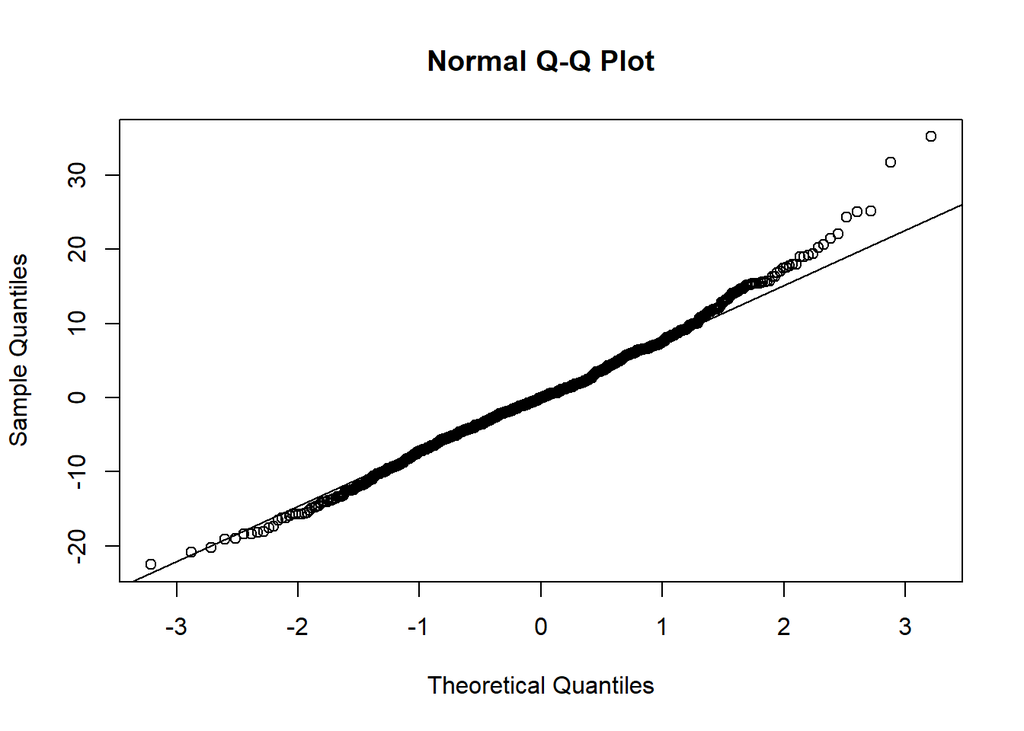

```r
qqnorm(Cement_str_robust$residuals)
qqline(Cement_str_robust$residuals)
```

```r
shapiro.test(Cement_str_robust$residuals)
```

```
##
##  Shapiro-Wilk normality test
##
## data:  Cement_str_robust$residuals
## W = 0.99187, p-value = 0.0003664
```

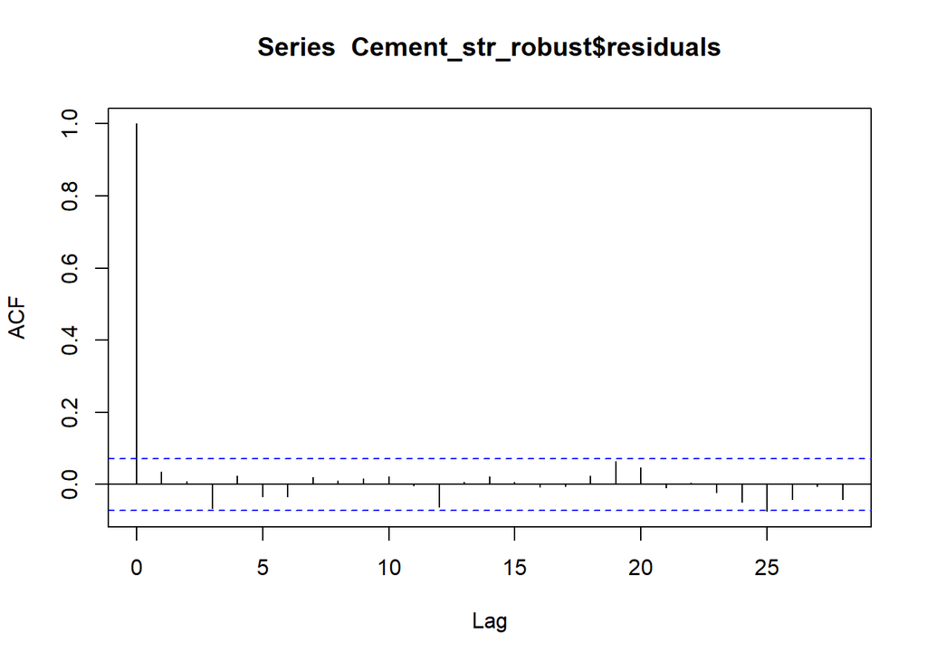

```r
################################################################################
acf(Cement_str_robust$residuals, type = "correlation")
#Kiem tra tinh tu tuong quan
acf(Cement_str_robust$residuals, type = "correlation")
```

```r
dwt(Cement_str_robust$residuals) # Khong co co so de bac bo H0: residual is not autocorrelated
```

```
## [1] 1.918407
```

```
## recomputing robust Mahalanobis distances
```

```
## saving the robust distances 'MD' as part of 'Cement_str_robust'
```

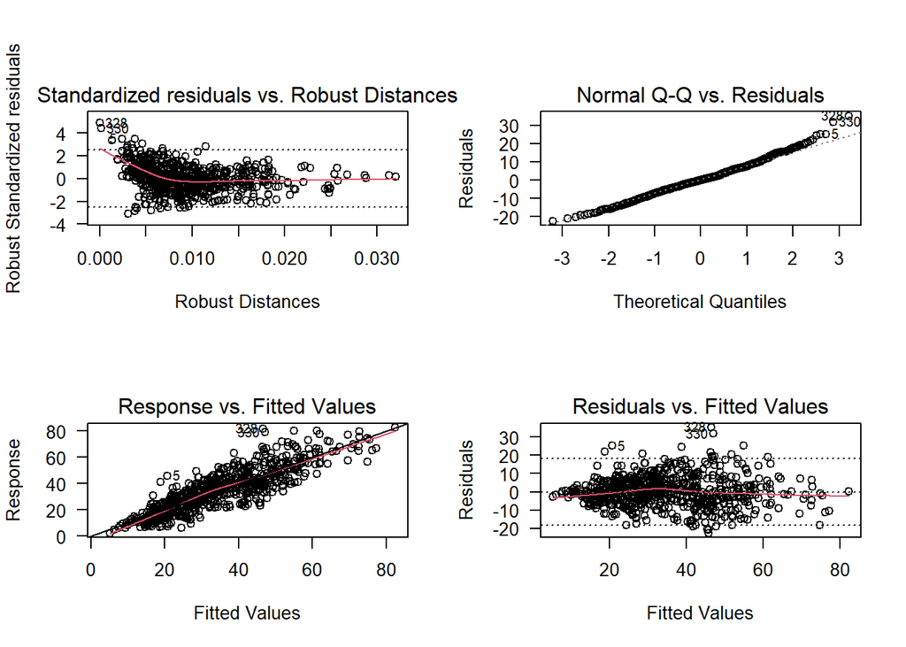

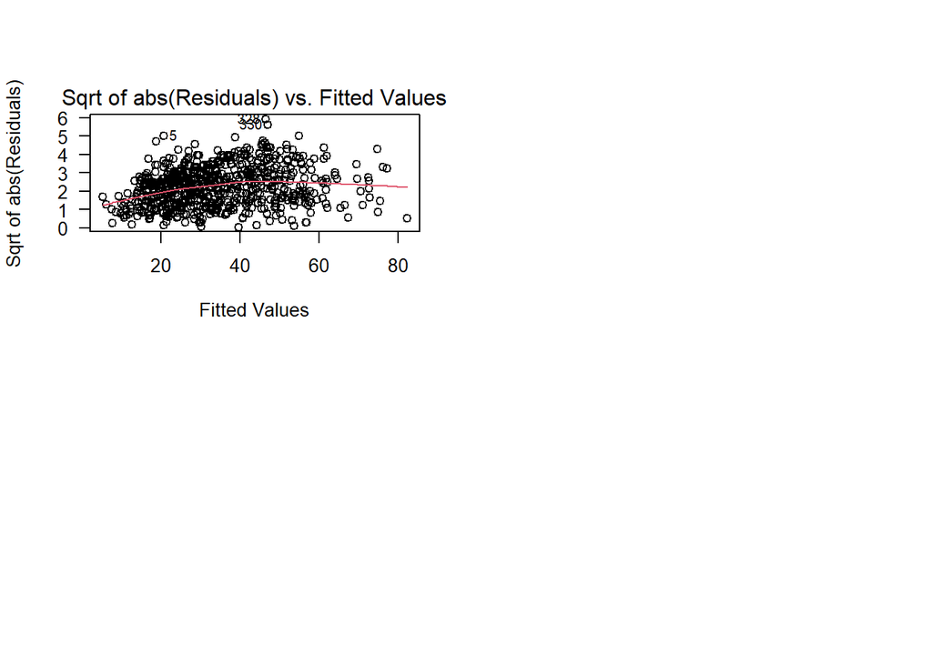

```r
################################################################################
opar <- par(mfrow = c(2,2), oma = c(0, 0, 1.1, 0))
plot(Cement_str_robust, las = 1)
```

## 3.3.5 Xây dựng mô hình Robust Regression cho tập train không bỏ ngoại lai

```r
################################################################################
################################################################################
# Mo hinh cho tap du lieu khon loai bo ngoai lai
###################################################
#Chuan bi tap train va tap valid
#Chuan bi tap train va tap valid
set.seed(2)
constant_balance = as.integer(0.8 * length(data$CCS))
cso_hang_cement = sample.int(length(data$CCS),constant_balance)

train_no_rel = data[cso_hang_cement,]
head(train_no_rel)
```

```
##     Cem_com   BFS    FA Water  SPz     CA  FA.1 Age   CCS
## 975   148.1   0.0 182.1 181.4 15.0  838.9 884.3  28 15.53
## 710   173.0 116.0   0.0 192.0  0.0  946.8 856.8  90 32.10
## 774   382.0   0.0   0.0 186.0  0.0 1047.0 739.0  28 37.42
## 416   250.0   0.0  95.7 191.8  5.3  948.9 857.2   3  8.49
## 392   397.0  17.2 158.0 167.0 20.8  967.0 633.0  28 55.65
## 273   231.8   0.0 121.6 174.0  6.7 1056.4 778.5  56 42.70
```

```r
dim(train_no_rel)
```

```
## [1] 824   9
```

```r
valid_no_rel = data[-cso_hang_cement,]
head(valid_no_rel)
```

```
##    Cem_com   BFS FA Water SPz   CA  FA.1 Age   CCS
## 6    266.0 114.0  0   228   0  932 670.0  90 47.03
## 7    380.0  95.0  0   228   0  932 594.0 365 43.70
## 15   304.0  76.0  0   228   0  932 670.0  28 47.81
## 18   342.0  38.0  0   228   0  932 670.0 365 56.14
## 24   139.6 209.4  0   192   0 1047 806.9 180 44.21
## 27   380.0  95.0  0   228   0  932 594.0 270 41.15
```

```r
dim(valid_no_rel)
```

```
## [1] 206   9
```

```r
# Mo hinh hoi quy robust cho tạp train_no_rel khong bo ngoai lai
Cement_str_robust_nrout <- lmrob(CCS ~  Cem_com + BFS + FA + SPz + Water + Age, data = train_no_rel)
summary(Cement_str_robust_nrout)
```

```
##
## Call:
## lmrob(formula = CCS ~ Cem_com + BFS + FA + SPz + Water + Age, data = train_no_rel)
##  \--> method = "MM"
## Residuals:
##      Min       1Q   Median       3Q      Max
## -85.5101  -6.0126  -0.5653   5.0268  32.8550
##
## Coefficients:
##              Estimate Std. Error t value Pr(>|t|)
## (Intercept) 20.513690   6.318297   3.247  0.00122 **
## Cem_com      0.108864   0.004706  23.133  < 2e-16 ***
## BFS          0.087318   0.006169  14.153  < 2e-16 ***
## FA           0.067830   0.009066   7.482 1.89e-13 ***
## SPz          0.175438   0.115160   1.523  0.12804
## Water       -0.202595   0.032582  -6.218 8.03e-10 ***
## Age          0.277829   0.030658   9.062  < 2e-16 ***
## ---
## Signif. codes:  0 '***' 0.001 '**' 0.01 '*' 0.05 '.' 0.1 ' ' 1
##
## Robust residual standard error: 8.064
## Multiple R-squared:  0.7578, Adjusted R-squared:  0.756
## Convergence in 35 IRWLS iterations
##
## Robustness weights:
##  21 observations c(149,171,233,280,302,319,320,359,361,408,445,455,467,536,539,553,620,675,716,794,814)
##   are outliers with |weight| = 0 ( < 0.00012);
##  66 weights are ~= 1. The remaining 737 ones are summarized as
##      Min.   1st Qu.    Median      Mean   3rd Qu.      Max.
## 0.0003913 0.8613000 0.9524000 0.8806000 0.9865000 0.9990000
## Algorithmic parameters:
##        tuning.chi                bb        tuning.psi        refine.tol
##         1.548e+00         5.000e-01         4.685e+00         1.000e-07
##           rel.tol         scale.tol         solve.tol       eps.outlier
##         1.000e-07         1.000e-10         1.000e-07         1.214e-04
##             eps.x warn.limit.reject warn.limit.meanrw
##         9.823e-10         5.000e-01         5.000e-01
##      nResample         max.it       best.r.s       k.fast.s          k.max
##            500             50              2              1            200
##    maxit.scale      trace.lev            mts     compute.rd fast.s.large.n
##            200              0           1000              0           2000
##                   psi           subsampling                   cov
##            "bisquare"         "nonsingular"         ".vcov.avar1"
## compute.outlier.stats
##                  "SM"
## seed : int(0)
```

```r
cbind(coef(Cement_str_robust_nrout),confint(Cement_str_robust_nrout, level = 0.95))
```

```
##                               2.5 %     97.5 %
## (Intercept) 20.51368973  8.11168216 32.9156973
## Cem_com      0.10886448  0.09962715  0.1181018
## BFS          0.08731817  0.07520844  0.0994279
## FA           0.06783038  0.05003507  0.0856257
## SPz          0.17543818 -0.05060579  0.4014822
## Water       -0.20259531 -0.26654981 -0.1386408
## Age          0.27782883  0.21765170  0.3380060
```

```r
Cement_str_robust_nrout$coefficients
```

```
## (Intercept)     Cem_com         BFS          FA         SPz       Water
## 20.51368973  0.10886448  0.08731817  0.06783038  0.17543818 -0.20259531
##         Age
##  0.27782883
```

```r
shapiro.test(Cement_str_robust_nrout$residuals)
```

```
##
##  Shapiro-Wilk normality test
##
## data:  Cement_str_robust_nrout$residuals
## W = 0.75675, p-value < 2.2e-16
```

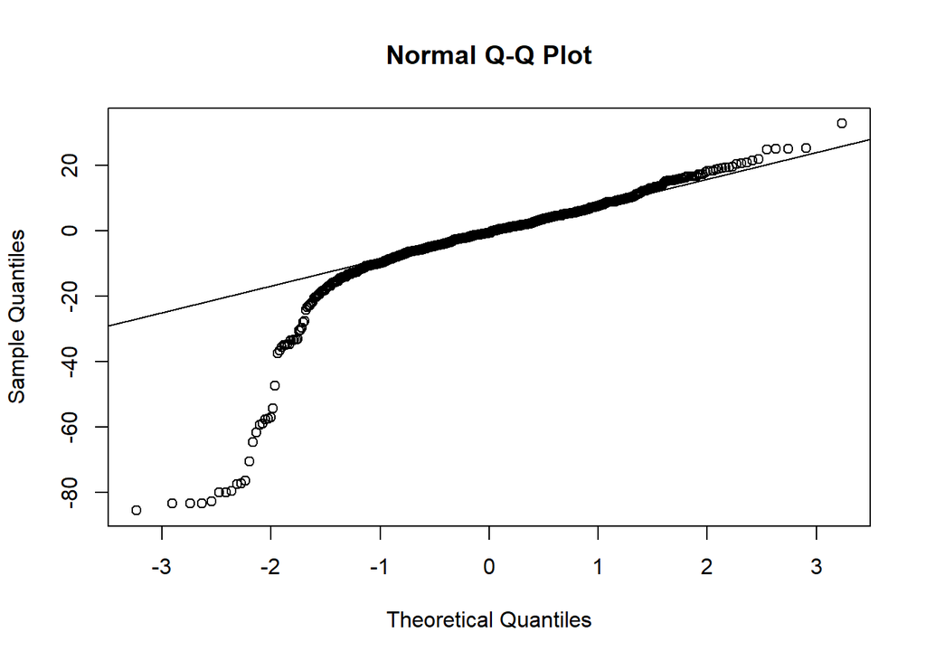

```r
qqnorm(Cement_str_robust_nrout$residuals)
qqline(Cement_str_robust_nrout$residuals)
```

```r
shapiro.test(Cement_str_robust_nrout$residuals)
```

```
##
##  Shapiro-Wilk normality test
##
## data:  Cement_str_robust_nrout$residuals
## W = 0.75675, p-value < 2.2e-16
```

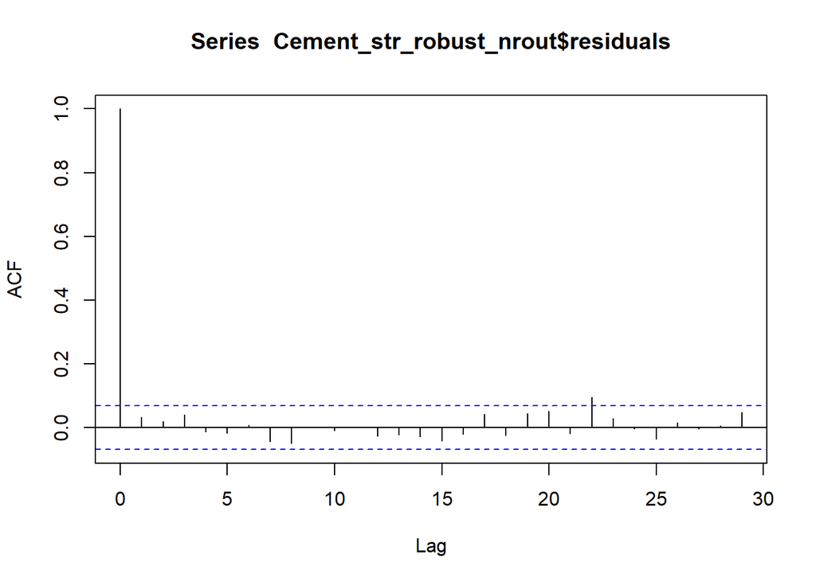

```r
################################################################################
acf(Cement_str_robust_nrout$residuals, type = "correlation")
#Kiem tra tinh tu tuong quan
acf(Cement_str_robust_nrout$residuals, type = "correlation")
```

```r
dwt(Cement_str_robust_nrout$residuals) # Khong co co so de bac bo H0: residual is not autocorrelated
```

```
## [1] 1.887915
```

```
## recomputing robust Mahalanobis distances
```

```
## saving the robust distances 'MD' as part of 'Cement_str_robust_nrout'
```

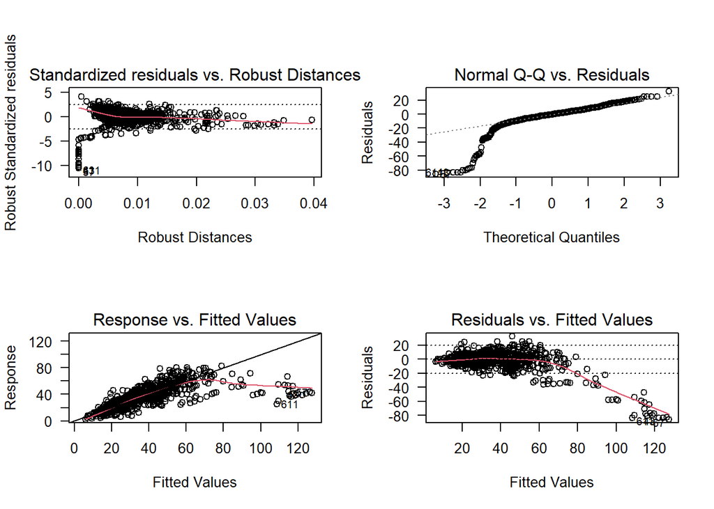

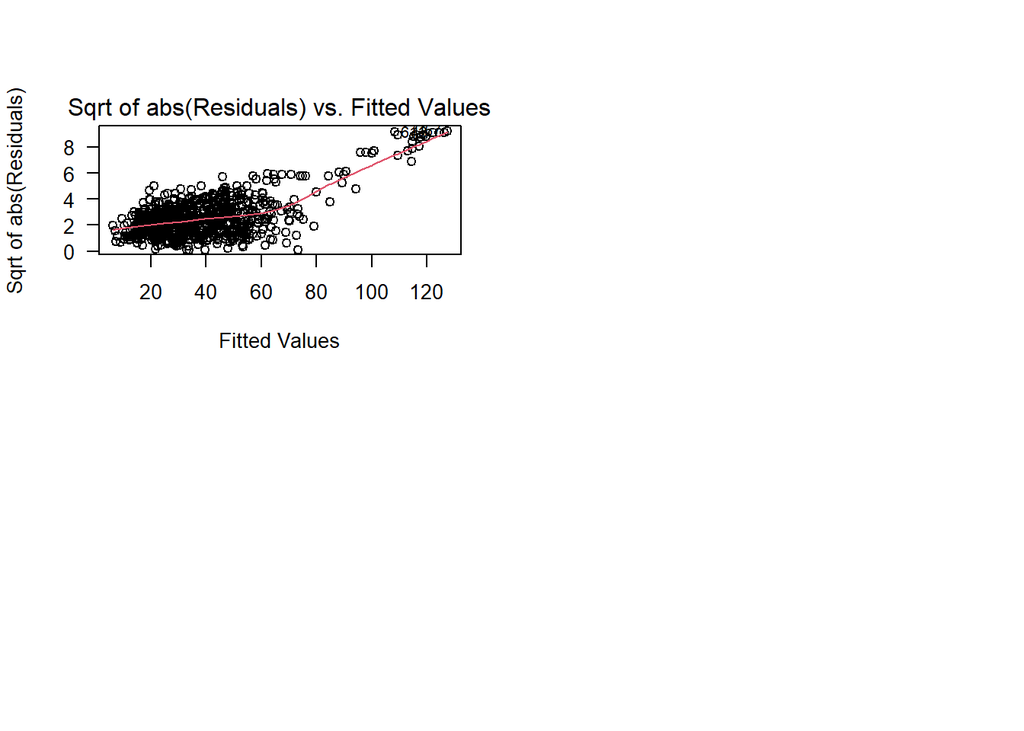

```r
################################################################################
opar <- par(mfrow = c(2,2), oma = c(0, 0, 1.1, 0))
plot(Cement_str_robust_nrout, las = 1)
```

# $4$. Kết luận (Results)

Trong mục $4$ này, chúng tôi trình bày các dự đoán nhờ vào các mô hình $\verb|Cement_str|$, $\verb|Cement_str_robust|$, $\verb|Cement_str_robust_nrout|$ cho các tập dữ liệu huân luyện và kiểm tra tương ứng với từng mô hình.

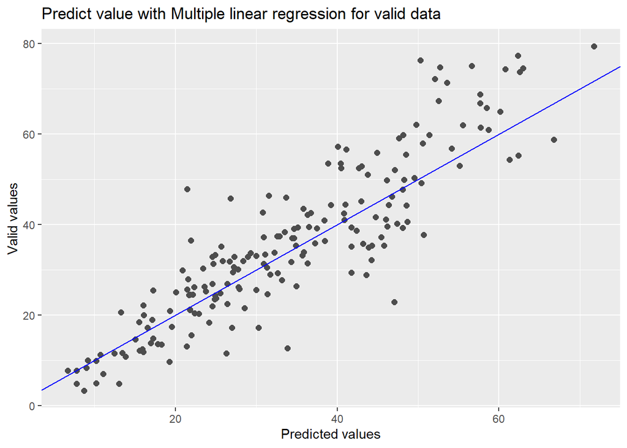

```r
################################################################################
#Predict on test data
predictvalid = predict(Cement_str, valid)
valid["Predicted"] = predictvalid
View(valid)
ggplot(valid, aes(valid$Predicted, valid$CCS)) +
  geom_point(size = 2, colour = "grey30") +
  geom_abline(intercept = 0, slope = 1, colour = "blue")+
  ggtitle("Predict value with Multiple linear regression for valid data") +
  labs(x="Predicted values", y="Valid values")
```

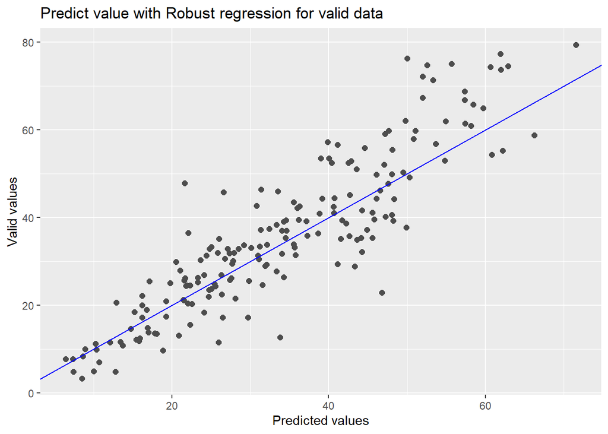

```r
################################################################################
#Predict on test data
predictvalid = predict(Cement_str_robust, valid)
valid["Predicted"] = predictvalid
View(valid)
ggplot(valid, aes(valid$Predicted, valid$CCS)) +
  geom_point(size = 2, colour = "grey30") +
  geom_abline(intercept = 0, slope = 1, colour = "blue")+
  ggtitle("Predict value with Robust regression for valid data") +
  labs(x="Predicted values", y="Valid values")
```

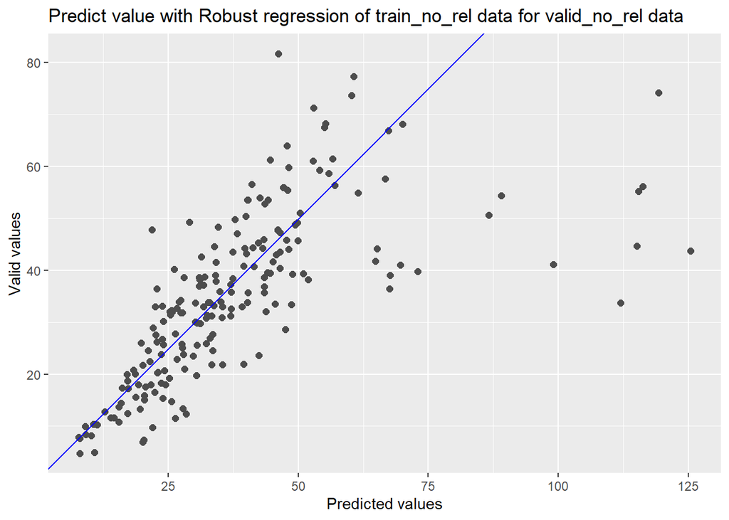

```r
################################################################################
#Predict on test data
predictvalid = predict(Cement_str_robust_nrout, valid_no_rel)
valid_no_rel["Predicted"] = predictvalid
View(valid_no_rel)
ggplot(valid_no_rel, aes(valid_no_rel$Predicted, valid_no_rel$CCS)) +
  geom_point(size = 2, colour = "grey30") +
  geom_abline(intercept = 0, slope = 1, colour = "blue")+
  ggtitle("Predict value with Robust regression of train_no_rel data for valid_no_rel data") +
  labs(x="Predicted values", y="Valid values")
```

# $5$. Bàn luận

Nhóm đã trình bày khái quát những phân tích liên quan đến tập dữ liệu $\verb|Concrete_Data.csv|$, sau đó xây dựng mô hình hồi quy cho các biến và đánh giá mối tương quan giữa các biến. Tuy nhiên, nhóm rút ra một số vấn đề và nhận xét như sau:

1. Các mô hình hồi quy xây dựng trong bài viết: hồi quy đơn, hồi quy đa thức,… tuy có phản ánh được mối quan hệ giữa những biến quan tâm, nhưng độ chính xác không cao. Có thể vì mô hình hồi quy được sử dụng chưa thực sự phù hợp, data chưa đủ lớn. Vì vậy, nếu có tác giả muốn phân tích tập dữ liệu này thì có thể cân nhắc để lựa chọn các mô hình phù hợp hơn.
2. Đối với việc phương sai thay đổi, nhóm đề xuất thực hiện mô hình hồi quy sai số chuẩn mạnh, tuy nhiên vẫn chưa thực hiện được.
3. Đối với việc phần tích phần dư của hồi quy Robust có một số biểu đồ nhóm vẫn chưa thể giải thích được và phần dư của hồi quy Robust thì không tuân theo phân phối chuẩn. Điều này dẫn đến nhóm đặt ra câu hỏi liệu mô hình này đã hiệu quả chưa và liệu rằng còn mô hình nào khác hiệu quả hơn.
4. Trong quá trình tìm kiếm tập dữ liệu nhóm đã tìm thấy khá nhiều tập dữ liệu có nhiều N/A và các biến phân loại. Việc xử lý các tập dữ liệu này khá phức tạp và là vấn đề nhóm vẫn chưa thực hiện được.

Về ý nghĩa thực tiễn của các mô hình hồi quy tương ứng với tập dữ liệu trên, các mô hình cho thấy rằng việc gia tăng các thành phần $\verb|Cement|$(xi măng), $\verb|Blast Furnace Slag|$(xỉ hạt lò cao nghiền mịn) $\verb|Fly Ash|$ (tro bay) và phụ gia làm dẻo, giảm nước như $\verb|Superplasticizer|$ sẽ gia tăng cường độ chịu nén của betong nói riêng và độ vững chắc của betong nói chung. Mặt khác, thời gian để khô betong càng lâu, các phân tử nước thoát khỏi vật liệu betong thì độ vững chắc của betong cũng càng cao. Như vậy, dựa trên bài tiểu luận này chúng tôi đã tìm ra được các thành phần quan trọng và ảnh hưởng đến chất lượng của bê tông.

# $6$. Tài liệu tham khảo

1. John Fox & Sanford Weisberg. (8/10/2012).*Robust regression*. http://users.stat.umn.edu/~sandy/courses/8053/handouts/robust.pdf
2. Yan, X., & Su, X. (2009). *Linear regression analysis: theory and computing* (pp. 157-194). world scientific.
3. THE INVESTOPEDIA TEAM (July 26, 2022). *Variance Inflation Factor (VIF)*. Retrieved December 4, 2022, from https://www.investopedia.com/terms/v/variance-inflation-factor.asp
4. Renesh Bedre. *Durbin-Watson (DW) test for autocorrelation (with R code)*. https://www.reneshbedre.com/blog/durbin-watson-test.html
5. Prof. I-Cheng Yeh. *Concrete Compressive Strength* (August 3, 2007). https://archive.ics.uci.edu/ml/datasets/concrete+compressive+strength
6. Sheldon M. Ross. *Introduction to Probability and Statistics for Engineers and Scientists*, Third Edition.
7. Nguyễn Văn Tuấn. *Phân tích số liệu và biểu đồ bằng R*. Garvan Institute of Medical Research, Sydney, Australia.
8. Durbin Watson Test: What It Is in Statistics, With Examples. .
9. Compressive Strength Of Concrete | What you need to know.

# $7$. Bảng phân công công việc và bảng đánh giá chéo

# 7.1 Bảng phân công công việc

| Họ và tên | MSSV | Công việc |
| --- | --- | --- |
| Đinh Minh Hải | 4501101017 | Phân tích dữ liệu với R, File tiểu luận Rmd Cơ sở lý luận Robust-regression, Slide thuyết trình |
| Lê Hoàng Quân | 46.01.101.124 | Phân tích dữ liệu với R, Đặt vấn đề, Slide thuyết trình |
| Trương Như Ý | 46.01.101.200 | Cơ sở lý luận *AIC*, Kiểm định Durbin-Watson, File tiểu luận Rmd, Slide thuyết trình, Đặt vấn đề |
| Bùi Quang Huy | 46.01.101.052 | Cơ sở lý luận *BIC*, Robust regression |
| Đặng Nguyễn Anh Tuấn | 46.01.101.184 | Cơ sở lý luận *AIC* |
| Lý Kiều Văn | 42.01.101.175 | Cơ sở lý luận của mô hình hồi quy |
| Phù Quốc Vinh | 46.01.101.192 | Hỗ trợ |

# 7.2 Bảng đánh giá chéo

[output not shown]